# SIMULACIÓN MONTECARLO

## PROYECCIÓN DE MARGEN PARA EMPRESA FINANCIERA

**By:** *RAÚL ALEXIS VILLAFUERTE SALHUANA*

### Definición del problema:

Cada año, en los meses de octubre las Empresas del sector financiero, tales como Banco, Financieras y Cajas Municipales requieren proyectar sus ingresos y gastos correspondientes al año próximo, en este caso para el año 2022. Con la aplicación de simulación Montecarlo se pretende ayudar, específicamente a Financiera Confianza, en aproximar como terminarán sus ingresos y gastos proyectados. La fuerza de ventas considera asesores comerciales, quienes tienen como responsabilidad contactar a los clientes, evaluarlos y si califican procesar y desembolsar el crédito. Los ingresos resultan de la multiplicación del saldo de cartera y de la tasa de interés a la cual se coloca el crédito. El saldo de cartera es resultado de la fórmula que sigue:

𝑠𝑎𝑙𝑑𝑜 𝑐𝑎𝑟𝑡𝑒𝑟𝑎 𝑓𝑖𝑛𝑎𝑙 = 𝑠𝑎𝑙𝑑𝑜 𝑐𝑎𝑟𝑡𝑒𝑟𝑎 𝑖𝑛𝑖𝑐𝑖𝑎𝑙 + 𝑑𝑒𝑠𝑒𝑚𝑏𝑜𝑙𝑠𝑜𝑠 − 𝑎𝑚𝑜𝑟𝑡𝑖𝑧𝑎𝑐𝑖ó𝑛

Donde saldo cartera inicial es el saldo al cierre de mes anterior, desembolsos es el monto colocado en el mes en curso y la amortización los pagos al capital de los créditos. Para el monto de desembolso se requiere considerar lo siguiente:

𝐷𝑒𝑠𝑒𝑚𝑏𝑜𝑙𝑠𝑜𝑠 = 𝑇𝑖𝑐𝑘𝑒𝑡 𝑥 𝑃𝑟𝑜𝑑𝑢𝑐𝑡𝑖𝑣𝑖𝑑𝑎𝑑 𝑥 𝑁𝑟𝑜 𝑎𝑠𝑒𝑠𝑜𝑟𝑒𝑠

Donde el ticket es el monto promedio de crédito otorgado al cliente, productividad es el número de operaciones que realiza el asesor comercial en el mes y número de asesores es la cantidad de asesores comerciales (vendedores de servicios financieros) que dispone la Financiera en un mes dado. La amortización es una función del saldo de cartera del mes anterior. De la data proporcionada por la Financiera, se tiene que la amortización es un 10% del saldo de cartera del mes anterior. Esta aproximación se usará al momento de realizar la proyección.

### 2. OBJETIVO:

Estimar el margen de ganancia/pérdida de la Financiera para el año 2022 utilizando técnicas de simulación Montecarlo.

### 3.VARIABLES ASOCIADAS AL ESTUDIO

Saldo de cartera: Stock de cartera de activas a una determinada fecha de corte

Ticket: Promedio de monto desembolso del mes

Productividad: Número de operaciones realizadas por el asesor en un mes

Nro de asesores: Cantidad de asesores comerciales (vendedores)

Amortización: Pagos al capital por los préstamos de dinero realizados.

Tasa de interés: Tasa promedio ponderada a la cuál se desembolsan los créditos

Gastos financieros: Pago de interes a los ahorristas, pago de fondeo

Gastos operativos: Sueldos de colaboradores

Gastos generales: Pago de servicios de agua, luz, internet, alquiler de local, etc.

Gastos de provisión: Gasto por deterioro de cartera

### 4. CONSTRUCCIÓN DEL MODELO DE SIMULACIÓN

```python
# Importando librerías
import numpy as np
import pandas as pd
import seaborn as sns
import matplotlib.pyplot as plt
from numpy import random
```

```python
#Creando lista de 500 números entre 20 y 25 (Productividad)
lst = [random.randint(20,25) for x in range(500)]
print(lst)
```

```
[20, 24, 20, 21, 23, 23, 20, 22, 20, 24, 23, 24, 22, 20, 23, 24, 20, 23, 20, 23, 22, 22, 20, 21, 20, 23, 20, 20, 23, 23, 24, 22, 20, 22, 20, 20, 23, 23, 22, 23, 23, 20, 20, 23, 20, 22, 24, 22, 23, 20, 21, 22, 20, 22, 21, 22, 21, 22, 22, 22, 24, 21, 21, 21, 21, 23, 21, 22, 21, 22, 24, 23, 21, 20, 23,…
```

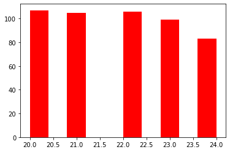

```python
#Graficando como barra la distribucción de números al azar
plt.hist(lst,10,color='red')
plt.show()
```

```python
# Convertir la lista a un array
from numpy import array
arr = array(lst)
arr
```

```
array([20, 24, 20, 21, 23, 23, 20, 22, 20, 24, 23, 24, 22, 20, 23, 24, 20,
       23, 20, 23, 22, 22, 20, 21, 20, 23, 20, 20, 23, 23, 24, 22, 20, 22,
       20, 20, 23, 23, 22, 23, 23, 20, 20, 23, 20, 22, 24, 22, 23, 20, 21,
       22, 20, 22, 21, 22, 21, 22, 22, 22, 24, 21, 21, 21, 21, 23, 21, 22,
       21, 22, 24, 23, 21, 20, 23, 21, 20, 23, 20, 24, 23, 23, 20, 22, 23,
       21, 20, 24, 22, 21, 24, 24, 21, 21, 21, 22, 22, 22, 21, 20, 22, 22,
       24, 20, 21, 21, 22, 24, 22, 21, 22, 24, 20, 20, 23, 22, 20, 24, 21,
       20, 20, 21, 20, 24, 20, 22, 24, 21, 21, 23, 22, 24, 21, 22, 24, 21,
       20, 23, 24, 23, 21, 20, 22, 24, 22, 24, 21, 20, 21, 24, 22, 22, 24,
       24, 23, 24, 20, 21, 20, 21, 22, 22, 21, 20, 21, 23, 21, 20, 22, 24,
       22, 20, 22, 24, 24, 22, 24, 22, 23, 20, 24, 22, 20, 21, 20, 21, 20,
       23, 24, 23, 22, 24, 23, 21, 21, 21, 21, 24, 23, 23, 22, 23, 20, 24,
       22, 23, 20, 22, 21, 23, 20, 23, 21, 23, 20, 21, 24, 22, 21, 23, 22,
       24, 24, 24, 20, 21, 22, 22, 20, 23, 21, 21, 21, 21, 22, 24, 23, 22,
       24, 21, 21, 21, 22, 22, 22, 24, 23, 22, 20, 20, 20, 22, 24, 24, 20,
       23, 22, 21, 23, 21, 23, 22, 21, 24, 23, 20, 20, 21, 23, 23, 23, 23,
       24, 21, 24, 21, 20, 21, 21, 23, 23, 23, 20, 24, 24, 22, 24, 22, 20,
       20, 23, 21, 23, 20, 23, 20, 23, 20, 23, 23, 23, 22, 20, 20, 24, 20,
       23, 21, 22, 24, 21, 20, 20, 21, 23, 22, 22, 23, 24, 21, 21, 22, 21,
       20, 21, 24, 21, 20, 20, 23, 24, 21, 22, 21, 22, 22, 22, 22, 22, 20,
       20, 23, 24, 23, 24, 21, 23, 22, 20, 24, 22, 22, 24, 21, 21, 24, 23,
       22, 21, 24, 23, 21, 22, 22, 21, 22, 22, 22, 24, 20, 22, 21, 21, 21,
       23, 20, 23, 20, 20, 23, 21, 21, 23, 21, 21, 22, 21, 23, 23, 20, 23,
       22, 20, 24, 20, 24, 23, 23, 23, 20, 22, 24, 22, 22, 21, 24, 22, 22,
       22, 21, 22, 21, 21, 22, 24, 20, 23, 20, 20, 24, 20, 22, 21, 23, 24,
       21, 21, 23, 24, 21, 22, 20, 21, 20, 22, 20, 20, 21, 20, 24, 22, 23,
       22, 22, 20, 22, 21, 24, 23, 20, 23, 23, 24, 22, 20, 21, 23, 20, 20,
       21, 24, 20, 22, 20, 23, 21, 24, 23, 21, 22, 22, 24, 20, 23, 23, 21,
       22, 23, 20, 23, 20, 22, 24, 21, 24, 21, 20, 20, 23, 24, 24, 24, 23,
       24, 23, 23, 20, 23, 20, 20])
```

## Preparación de datos

```python
#Función todf (convertir en dataframe)
from funpymodeling.data_prep import todf
df = todf(arr)
df
```

|  | 0 |
| --- | --- |
| 0 | 20 |
| 1 | 24 |
| 2 | 20 |
| 3 | 21 |
| 4 | 23 |
| ... | ... |
| 495 | 23 |
| 496 | 20 |
| 497 | 23 |
| 498 | 20 |
| 499 | 20 |

500 rows × 1 columns

```python
df = df.reset_index()
df
```

|  | index | 0 |
| --- | --- | --- |
| 0 | 0 | 20 |
| 1 | 1 | 24 |
| 2 | 2 | 20 |
| 3 | 3 | 21 |
| 4 | 4 | 23 |
| ... | ... | ... |
| 495 | 495 | 23 |
| 496 | 496 | 20 |
| 497 | 497 | 23 |
| 498 | 498 | 20 |
| 499 | 499 | 20 |

500 rows × 2 columns

```python
df.rename(columns = {"index": "Id",
                     0:"Productividad"},inplace = True)
```

```python
df
```

|  | Id | Productividad |
| --- | --- | --- |
| 0 | 0 | 20 |
| 1 | 1 | 24 |
| 2 | 2 | 20 |
| 3 | 3 | 21 |
| 4 | 4 | 23 |
| ... | ... | ... |
| 495 | 495 | 23 |
| 496 | 496 | 20 |
| 497 | 497 | 23 |
| 498 | 498 | 20 |
| 499 | 499 | 20 |

500 rows × 2 columns

Como podemos ver ya se ha generado los valores aleatorios de productividad (número de operaciones en el mes) de los asesores comerciales.

Luego, por cada valor aleatorio generado se hace el cálculo del margen (ingresos – gastos) utilizando un Estado de Pérdidas y Ganancias de la Empresa

*Para calcular los ingresos y desembolsos se tiene que tener un margen de proyección en forma de cartera:*

```
Cartera octubre 2021:                2100000000 soles

Ticket:                              7500       soles

Nro asesores:                        1000

Tasa de interés:                     25%

Tasa amortización:                   10%

Gastos Total / Ing. financieros:     96.5%
```

Comenzando desde el mes de Octubre: 2100000000

# *OCTUBRE 2021*

# Saldo

```python
# Creando una lista de números de 2 100 000 000
lst1= list(range(2100000000,2100000499+1))
saldo_oct21 = array(lst1)
saldo_oct21
```

```
array([2100000000, 2100000001, 2100000002, 2100000003, 2100000004,
       2100000005, 2100000006, 2100000007, 2100000008, 2100000009,
       2100000010, 2100000011, 2100000012, 2100000013, 2100000014,
       2100000015, 2100000016, 2100000017, 2100000018, 2100000019,
       2100000020, 2100000021, 2100000022, 2100000023, 2100000024,
       2100000025, 2100000026, 2100000027, 2100000028, 2100000029,
       2100000030, 2100000031, 2100000032, 2100000033, 2100000034,
       2100000035, 2100000036, 2100000037, 2100000038, 2100000039,
       2100000040, 2100000041, 2100000042, 2100000043, 2100000044,
       2100000045, 2100000046, 2100000047, 2100000048, 2100000049,
       2100000050, 2100000051, 2100000052, 2100000053, 2100000054,
       2100000055, 2100000056, 2100000057, 2100000058, 2100000059,
       2100000060, 2100000061, 2100000062, 2100000063, 2100000064,
       2100000065, 2100000066, 2100000067, 2100000068, 2100000069,
       2100000070, 2100000071, 2100000072, 2100000073, 2100000074,
```

[output cut: 85 more lines]

```python
df1 = todf(saldo_oct21)
df1
df1.rename(columns = {0:"Saldo_Oct21"},inplace = True)
df1
```

|  | Saldo_Oct21 |
| --- | --- |
| 0 | 2100000000 |
| 1 | 2100000001 |
| 2 | 2100000002 |
| 3 | 2100000003 |
| 4 | 2100000004 |
| ... | ... |
| 495 | 2100000495 |
| 496 | 2100000496 |
| 497 | 2100000497 |
| 498 | 2100000498 |
| 499 | 2100000499 |

500 rows × 1 columns

# *NOVIEMBRE 2021*

# Desembolso

```python
Desemb_nov21 = arr * 7500 *1000
Desemb_nov21
```

```
array([150000000, 180000000, 150000000, 157500000, 172500000, 172500000,
       150000000, 165000000, 150000000, 180000000, 172500000, 180000000,
       165000000, 150000000, 172500000, 180000000, 150000000, 172500000,
       150000000, 172500000, 165000000, 165000000, 150000000, 157500000,
       150000000, 172500000, 150000000, 150000000, 172500000, 172500000,
       180000000, 165000000, 150000000, 165000000, 150000000, 150000000,
       172500000, 172500000, 165000000, 172500000, 172500000, 150000000,
       150000000, 172500000, 150000000, 165000000, 180000000, 165000000,
       172500000, 150000000, 157500000, 165000000, 150000000, 165000000,
       157500000, 165000000, 157500000, 165000000, 165000000, 165000000,
       180000000, 157500000, 157500000, 157500000, 157500000, 172500000,
       157500000, 165000000, 157500000, 165000000, 180000000, 172500000,
       157500000, 150000000, 172500000, 157500000, 150000000, 172500000,
       150000000, 180000000, 172500000, 172500000, 150000000, 165000000,
       172500000, 157500000, 150000000, 180000000, 165000000, 157500000,
```

[output cut: 69 more lines]

```python
df2 = todf(Desemb_nov21)
df2
df2.rename(columns = {0:"Desemb_Nov21"},inplace = True)
df2
```

|  | Desemb_Nov21 |
| --- | --- |
| 0 | 150000000 |
| 1 | 180000000 |
| 2 | 150000000 |
| 3 | 157500000 |
| 4 | 172500000 |
| ... | ... |
| 495 | 172500000 |
| 496 | 150000000 |
| 497 | 172500000 |
| 498 | 150000000 |
| 499 | 150000000 |

500 rows × 1 columns

# Amortización

```python
#Considerando un 10% amortización
Amort_nov21 = saldo_oct21 *0.1
Amort_nov21
```

```
array([2.10000000e+08, 2.10000000e+08, 2.10000000e+08, 2.10000000e+08,
       2.10000000e+08, 2.10000000e+08, 2.10000001e+08, 2.10000001e+08,
       2.10000001e+08, 2.10000001e+08, 2.10000001e+08, 2.10000001e+08,
       2.10000001e+08, 2.10000001e+08, 2.10000001e+08, 2.10000002e+08,
       2.10000002e+08, 2.10000002e+08, 2.10000002e+08, 2.10000002e+08,
       2.10000002e+08, 2.10000002e+08, 2.10000002e+08, 2.10000002e+08,
       2.10000002e+08, 2.10000002e+08, 2.10000003e+08, 2.10000003e+08,
       2.10000003e+08, 2.10000003e+08, 2.10000003e+08, 2.10000003e+08,
       2.10000003e+08, 2.10000003e+08, 2.10000003e+08, 2.10000004e+08,
       2.10000004e+08, 2.10000004e+08, 2.10000004e+08, 2.10000004e+08,
       2.10000004e+08, 2.10000004e+08, 2.10000004e+08, 2.10000004e+08,
       2.10000004e+08, 2.10000004e+08, 2.10000005e+08, 2.10000005e+08,
       2.10000005e+08, 2.10000005e+08, 2.10000005e+08, 2.10000005e+08,
       2.10000005e+08, 2.10000005e+08, 2.10000005e+08, 2.10000006e+08,
       2.10000006e+08, 2.10000006e+08, 2.10000006e+08, 2.10000006e+08,
       2.10000006e+08, 2.10000006e+08, 2.10000006e+08, 2.10000006e+08,
       2.10000006e+08, 2.10000006e+08, 2.10000007e+08, 2.10000007e+08,
       2.10000007e+08, 2.10000007e+08, 2.10000007e+08, 2.10000007e+08,
       2.10000007e+08, 2.10000007e+08, 2.10000007e+08, 2.10000008e+08,
       2.10000008e+08, 2.10000008e+08, 2.10000008e+08, 2.10000008e+08,
       2.10000008e+08, 2.10000008e+08, 2.10000008e+08, 2.10000008e+08,
       2.10000008e+08, 2.10000008e+08, 2.10000009e+08, 2.10000009e+08,
       2.10000009e+08, 2.10000009e+08, 2.10000009e+08, 2.10000009e+08,
       2.10000009e+08, 2.10000009e+08, 2.10000009e+08, 2.10000010e+08,
       2.10000010e+08, 2.10000010e+08, 2.10000010e+08, 2.10000010e+08,
       2.10000010e+08, 2.10000010e+08, 2.10000010e+08, 2.10000010e+08,
       2.10000010e+08, 2.10000010e+08, 2.10000011e+08, 2.10000011e+08,
       2.10000011e+08, 2.10000011e+08, 2.10000011e+08, 2.10000011e+08,
       2.10000011e+08, 2.10000011e+08, 2.10000011e+08, 2.10000012e+08,
       2.10000012e+08, 2.10000012e+08, 2.10000012e+08, 2.10000012e+08,
       2.10000012e+08, 2.10000012e+08, 2.10000012e+08, 2.10000012e+08,
       2.10000012e+08, 2.10000012e+08, 2.10000013e+08, 2.10000013e+08,
       2.10000013e+08, 2.10000013e+08, 2.10000013e+08, 2.10000013e+08,
       2.10000013e+08, 2.10000013e+08, 2.10000013e+08, 2.10000014e+08,
       2.10000014e+08, 2.10000014e+08, 2.10000014e+08, 2.10000014e+08,
       2.10000014e+08, 2.10000014e+08, 2.10000014e+08, 2.10000014e+08,
       2.10000014e+08, 2.10000014e+08, 2.10000015e+08, 2.10000015e+08,
       2.10000015e+08, 2.10000015e+08, 2.10000015e+08, 2.10000015e+08,
       2.10000015e+08, 2.10000015e+08, 2.10000015e+08, 2.10000016e+08,
       2.10000016e+08, 2.10000016e+08, 2.10000016e+08, 2.10000016e+08,
```

[output cut: 70 more lines]

```
       2.10000044e+08, 2.10000044e+08, 2.10000044e+08, 2.10000044e+08,
       2.10000044e+08, 2.10000044e+08, 2.10000045e+08, 2.10000045e+08,
       2.10000045e+08, 2.10000045e+08, 2.10000045e+08, 2.10000045e+08,
       2.10000045e+08, 2.10000045e+08, 2.10000045e+08, 2.10000046e+08,
       2.10000046e+08, 2.10000046e+08, 2.10000046e+08, 2.10000046e+08,
       2.10000046e+08, 2.10000046e+08, 2.10000046e+08, 2.10000046e+08,
       2.10000046e+08, 2.10000046e+08, 2.10000047e+08, 2.10000047e+08,
       2.10000047e+08, 2.10000047e+08, 2.10000047e+08, 2.10000047e+08,
       2.10000047e+08, 2.10000047e+08, 2.10000047e+08, 2.10000048e+08,
       2.10000048e+08, 2.10000048e+08, 2.10000048e+08, 2.10000048e+08,
       2.10000048e+08, 2.10000048e+08, 2.10000048e+08, 2.10000048e+08,
       2.10000048e+08, 2.10000048e+08, 2.10000049e+08, 2.10000049e+08,
       2.10000049e+08, 2.10000049e+08, 2.10000049e+08, 2.10000049e+08,
       2.10000049e+08, 2.10000049e+08, 2.10000049e+08, 2.10000050e+08,
       2.10000050e+08, 2.10000050e+08, 2.10000050e+08, 2.10000050e+08])
```

```python
df3 = todf(Amort_nov21)
df3
df3.rename(columns = {0:"Amort_Nov21"},inplace = True)
df3
```

|  | Amort_Nov21 |
| --- | --- |
| 0 | 210000000.0 |
| 1 | 210000000.1 |
| 2 | 210000000.2 |
| 3 | 210000000.3 |
| 4 | 210000000.4 |
| ... | ... |
| 495 | 210000049.5 |
| 496 | 210000049.6 |
| 497 | 210000049.7 |
| 498 | 210000049.8 |
| 499 | 210000049.9 |

500 rows × 1 columns

# Ingresos Financieros

```python
#Considerando un 25% de tasa de interés
IngFin_nov21 = saldo_oct21 *0.25
IngFin_nov21
```

```
array([5.25000000e+08, 5.25000000e+08, 5.25000000e+08, 5.25000001e+08,
       5.25000001e+08, 5.25000001e+08, 5.25000002e+08, 5.25000002e+08,
       5.25000002e+08, 5.25000002e+08, 5.25000002e+08, 5.25000003e+08,
       5.25000003e+08, 5.25000003e+08, 5.25000004e+08, 5.25000004e+08,
       5.25000004e+08, 5.25000004e+08, 5.25000004e+08, 5.25000005e+08,
       5.25000005e+08, 5.25000005e+08, 5.25000006e+08, 5.25000006e+08,
       5.25000006e+08, 5.25000006e+08, 5.25000006e+08, 5.25000007e+08,
       5.25000007e+08, 5.25000007e+08, 5.25000008e+08, 5.25000008e+08,
       5.25000008e+08, 5.25000008e+08, 5.25000008e+08, 5.25000009e+08,
       5.25000009e+08, 5.25000009e+08, 5.25000010e+08, 5.25000010e+08,
       5.25000010e+08, 5.25000010e+08, 5.25000010e+08, 5.25000011e+08,
       5.25000011e+08, 5.25000011e+08, 5.25000012e+08, 5.25000012e+08,
       5.25000012e+08, 5.25000012e+08, 5.25000012e+08, 5.25000013e+08,
       5.25000013e+08, 5.25000013e+08, 5.25000014e+08, 5.25000014e+08,
       5.25000014e+08, 5.25000014e+08, 5.25000014e+08, 5.25000015e+08,
       5.25000015e+08, 5.25000015e+08, 5.25000016e+08, 5.25000016e+08,
       5.25000016e+08, 5.25000016e+08, 5.25000016e+08, 5.25000017e+08,
       5.25000017e+08, 5.25000017e+08, 5.25000018e+08, 5.25000018e+08,
       5.25000018e+08, 5.25000018e+08, 5.25000018e+08, 5.25000019e+08,
       5.25000019e+08, 5.25000019e+08, 5.25000020e+08, 5.25000020e+08,
       5.25000020e+08, 5.25000020e+08, 5.25000020e+08, 5.25000021e+08,
       5.25000021e+08, 5.25000021e+08, 5.25000022e+08, 5.25000022e+08,
       5.25000022e+08, 5.25000022e+08, 5.25000022e+08, 5.25000023e+08,
       5.25000023e+08, 5.25000023e+08, 5.25000024e+08, 5.25000024e+08,
       5.25000024e+08, 5.25000024e+08, 5.25000024e+08, 5.25000025e+08,
       5.25000025e+08, 5.25000025e+08, 5.25000026e+08, 5.25000026e+08,
       5.25000026e+08, 5.25000026e+08, 5.25000026e+08, 5.25000027e+08,
       5.25000027e+08, 5.25000027e+08, 5.25000028e+08, 5.25000028e+08,
       5.25000028e+08, 5.25000028e+08, 5.25000028e+08, 5.25000029e+08,
       5.25000029e+08, 5.25000029e+08, 5.25000030e+08, 5.25000030e+08,
       5.25000030e+08, 5.25000030e+08, 5.25000030e+08, 5.25000031e+08,
       5.25000031e+08, 5.25000031e+08, 5.25000032e+08, 5.25000032e+08,
       5.25000032e+08, 5.25000032e+08, 5.25000032e+08, 5.25000033e+08,
       5.25000033e+08, 5.25000033e+08, 5.25000034e+08, 5.25000034e+08,
       5.25000034e+08, 5.25000034e+08, 5.25000034e+08, 5.25000035e+08,
       5.25000035e+08, 5.25000035e+08, 5.25000036e+08, 5.25000036e+08,
       5.25000036e+08, 5.25000036e+08, 5.25000036e+08, 5.25000037e+08,
       5.25000037e+08, 5.25000037e+08, 5.25000038e+08, 5.25000038e+08,
       5.25000038e+08, 5.25000038e+08, 5.25000038e+08, 5.25000039e+08,
       5.25000039e+08, 5.25000039e+08, 5.25000040e+08, 5.25000040e+08,
```

[output cut: 70 more lines]

```
       5.25000110e+08, 5.25000110e+08, 5.25000110e+08, 5.25000111e+08,
       5.25000111e+08, 5.25000111e+08, 5.25000112e+08, 5.25000112e+08,
       5.25000112e+08, 5.25000112e+08, 5.25000112e+08, 5.25000113e+08,
       5.25000113e+08, 5.25000113e+08, 5.25000114e+08, 5.25000114e+08,
       5.25000114e+08, 5.25000114e+08, 5.25000114e+08, 5.25000115e+08,
       5.25000115e+08, 5.25000115e+08, 5.25000116e+08, 5.25000116e+08,
       5.25000116e+08, 5.25000116e+08, 5.25000116e+08, 5.25000117e+08,
       5.25000117e+08, 5.25000117e+08, 5.25000118e+08, 5.25000118e+08,
       5.25000118e+08, 5.25000118e+08, 5.25000118e+08, 5.25000119e+08,
       5.25000119e+08, 5.25000119e+08, 5.25000120e+08, 5.25000120e+08,
       5.25000120e+08, 5.25000120e+08, 5.25000120e+08, 5.25000121e+08,
       5.25000121e+08, 5.25000121e+08, 5.25000122e+08, 5.25000122e+08,
       5.25000122e+08, 5.25000122e+08, 5.25000122e+08, 5.25000123e+08,
       5.25000123e+08, 5.25000123e+08, 5.25000124e+08, 5.25000124e+08,
       5.25000124e+08, 5.25000124e+08, 5.25000124e+08, 5.25000125e+08])
```

```python
df4 = todf(IngFin_nov21)
df4
df4.rename(columns = {0:"IngFin_Nov21"},inplace = True)
df4
```

|  | IngFin_Nov21 |
| --- | --- |
| 0 | 525000000.0 |
| 1 | 525000000.25 |
| 2 | 525000000.5 |
| 3 | 525000000.75 |
| 4 | 525000001.0 |
| ... | ... |
| 495 | 525000123.75 |
| 496 | 525000124.0 |
| 497 | 525000124.25 |
| 498 | 525000124.5 |
| 499 | 525000124.75 |

500 rows × 1 columns

# Gastos total

```python
# Considerando un 96.50% de Gastos total/Ing. Financieros
GastTot_nov21 = IngFin_nov21*0.965
GastTot_nov21
```

```
array([5.06625000e+08, 5.06625000e+08, 5.06625000e+08, 5.06625001e+08,
       5.06625001e+08, 5.06625001e+08, 5.06625001e+08, 5.06625002e+08,
       5.06625002e+08, 5.06625002e+08, 5.06625002e+08, 5.06625003e+08,
       5.06625003e+08, 5.06625003e+08, 5.06625003e+08, 5.06625004e+08,
       5.06625004e+08, 5.06625004e+08, 5.06625004e+08, 5.06625005e+08,
       5.06625005e+08, 5.06625005e+08, 5.06625005e+08, 5.06625006e+08,
       5.06625006e+08, 5.06625006e+08, 5.06625006e+08, 5.06625007e+08,
       5.06625007e+08, 5.06625007e+08, 5.06625007e+08, 5.06625007e+08,
       5.06625008e+08, 5.06625008e+08, 5.06625008e+08, 5.06625008e+08,
       5.06625009e+08, 5.06625009e+08, 5.06625009e+08, 5.06625009e+08,
       5.06625010e+08, 5.06625010e+08, 5.06625010e+08, 5.06625010e+08,
       5.06625011e+08, 5.06625011e+08, 5.06625011e+08, 5.06625011e+08,
       5.06625012e+08, 5.06625012e+08, 5.06625012e+08, 5.06625012e+08,
       5.06625013e+08, 5.06625013e+08, 5.06625013e+08, 5.06625013e+08,
       5.06625014e+08, 5.06625014e+08, 5.06625014e+08, 5.06625014e+08,
       5.06625014e+08, 5.06625015e+08, 5.06625015e+08, 5.06625015e+08,
       5.06625015e+08, 5.06625016e+08, 5.06625016e+08, 5.06625016e+08,
       5.06625016e+08, 5.06625017e+08, 5.06625017e+08, 5.06625017e+08,
       5.06625017e+08, 5.06625018e+08, 5.06625018e+08, 5.06625018e+08,
       5.06625018e+08, 5.06625019e+08, 5.06625019e+08, 5.06625019e+08,
       5.06625019e+08, 5.06625020e+08, 5.06625020e+08, 5.06625020e+08,
       5.06625020e+08, 5.06625021e+08, 5.06625021e+08, 5.06625021e+08,
       5.06625021e+08, 5.06625021e+08, 5.06625022e+08, 5.06625022e+08,
       5.06625022e+08, 5.06625022e+08, 5.06625023e+08, 5.06625023e+08,
       5.06625023e+08, 5.06625023e+08, 5.06625024e+08, 5.06625024e+08,
       5.06625024e+08, 5.06625024e+08, 5.06625025e+08, 5.06625025e+08,
       5.06625025e+08, 5.06625025e+08, 5.06625026e+08, 5.06625026e+08,
       5.06625026e+08, 5.06625026e+08, 5.06625027e+08, 5.06625027e+08,
       5.06625027e+08, 5.06625027e+08, 5.06625028e+08, 5.06625028e+08,
       5.06625028e+08, 5.06625028e+08, 5.06625028e+08, 5.06625029e+08,
       5.06625029e+08, 5.06625029e+08, 5.06625029e+08, 5.06625030e+08,
       5.06625030e+08, 5.06625030e+08, 5.06625030e+08, 5.06625031e+08,
       5.06625031e+08, 5.06625031e+08, 5.06625031e+08, 5.06625032e+08,
       5.06625032e+08, 5.06625032e+08, 5.06625032e+08, 5.06625033e+08,
       5.06625033e+08, 5.06625033e+08, 5.06625033e+08, 5.06625034e+08,
       5.06625034e+08, 5.06625034e+08, 5.06625034e+08, 5.06625034e+08,
       5.06625035e+08, 5.06625035e+08, 5.06625035e+08, 5.06625035e+08,
       5.06625036e+08, 5.06625036e+08, 5.06625036e+08, 5.06625036e+08,
       5.06625037e+08, 5.06625037e+08, 5.06625037e+08, 5.06625037e+08,
       5.06625038e+08, 5.06625038e+08, 5.06625038e+08, 5.06625038e+08,
```

[output cut: 70 more lines]

```
       5.06625106e+08, 5.06625106e+08, 5.06625107e+08, 5.06625107e+08,
       5.06625107e+08, 5.06625107e+08, 5.06625108e+08, 5.06625108e+08,
       5.06625108e+08, 5.06625108e+08, 5.06625109e+08, 5.06625109e+08,
       5.06625109e+08, 5.06625109e+08, 5.06625110e+08, 5.06625110e+08,
       5.06625110e+08, 5.06625110e+08, 5.06625110e+08, 5.06625111e+08,
       5.06625111e+08, 5.06625111e+08, 5.06625111e+08, 5.06625112e+08,
       5.06625112e+08, 5.06625112e+08, 5.06625112e+08, 5.06625113e+08,
       5.06625113e+08, 5.06625113e+08, 5.06625113e+08, 5.06625114e+08,
       5.06625114e+08, 5.06625114e+08, 5.06625114e+08, 5.06625115e+08,
       5.06625115e+08, 5.06625115e+08, 5.06625115e+08, 5.06625116e+08,
       5.06625116e+08, 5.06625116e+08, 5.06625116e+08, 5.06625117e+08,
       5.06625117e+08, 5.06625117e+08, 5.06625117e+08, 5.06625117e+08,
       5.06625118e+08, 5.06625118e+08, 5.06625118e+08, 5.06625118e+08,
       5.06625119e+08, 5.06625119e+08, 5.06625119e+08, 5.06625119e+08,
       5.06625120e+08, 5.06625120e+08, 5.06625120e+08, 5.06625120e+08])
```

```python
df5 = todf(GastTot_nov21)
df5
df5.rename(columns = {0:"Gastos_Nov21"},inplace = True)
df5
```

|  | Gastos_Nov21 |
| --- | --- |
| 0 | 506625000.0 |
| 1 | 506625000.24125 |
| 2 | 506625000.4825 |
| 3 | 506625000.72375 |
| 4 | 506625000.965 |
| ... | ... |
| 495 | 506625119.41875 |
| 496 | 506625119.66 |
| 497 | 506625119.90125 |
| 498 | 506625120.1425 |
| 499 | 506625120.38375 |

500 rows × 1 columns

```python
listaNov21 = [arr,saldo_oct21,Desemb_nov21,Amort_nov21,IngFin_nov21,GastTot_nov21]
listaNov21
```

[output not shown]

[output cut: 534 more lines]

[output not shown]

```python
from funpymodeling.data_prep import todf
df_21 = todf(listaNov21)
df_21
```

|  | 0 | 1 | 2 | 3 | 4 | 5 | 6 | 7 | 8 | 9 | ... | 490 | 491 | 492 | 493 | 494 | 495 | 496 | 497 | 498 | 499 |
| --- | --- | --- | --- | --- | --- | --- | --- | --- | --- | --- | --- | --- | --- | --- | --- | --- | --- | --- | --- | --- | --- |
| 0 | 20 | 24.0 | 20.0 | 21.0 | 23.0 | 23.0 | 20.0 | 22.0 | 20.0 | 24.0 | ... | 24.0 | 24.0 | 23.0 | 24.0 | 23.0 | 23.0 | 20.0 | 23.0 | 20.0 | 20.0 |
| 1 | 2100000000 | 2100000001.0 | 2100000002.0 | 2100000003.0 | 2100000004.0 | 2100000005.0 | 2100000006.0 | 2100000007.0 | 2100000008.0 | 2100000009.0 | ... | 2100000490.0 | 2100000491.0 | 2100000492.0 | 2100000493.0 | 2100000494.0 | 2100000495.0 | 2100000496.0 | 2100000497.0 | 2100000498.0 | 2100000499.0 |
| 2 | 150000000 | 180000000.0 | 150000000.0 | 157500000.0 | 172500000.0 | 172500000.0 | 150000000.0 | 165000000.0 | 150000000.0 | 180000000.0 | ... | 180000000.0 | 180000000.0 | 172500000.0 | 180000000.0 | 172500000.0 | 172500000.0 | 150000000.0 | 172500000.0 | 150000000.0 | 150000000.0 |
| 3 | 210000000 | 210000000.1 | 210000000.2 | 210000000.3 | 210000000.4 | 210000000.5 | 210000000.6 | 210000000.7 | 210000000.8 | 210000000.9 | ... | 210000049.0 | 210000049.1 | 210000049.2 | 210000049.3 | 210000049.4 | 210000049.5 | 210000049.6 | 210000049.7 | 210000049.8 | 210000049.9 |
| 4 | 525000000 | 525000000.25 | 525000000.5 | 525000000.75 | 525000001.0 | 525000001.25 | 525000001.5 | 525000001.75 | 525000002.0 | 525000002.25 | ... | 525000122.5 | 525000122.75 | 525000123.0 | 525000123.25 | 525000123.5 | 525000123.75 | 525000124.0 | 525000124.25 | 525000124.5 | 525000124.75 |
| 5 | 506625000 | 506625000.24125 | 506625000.4825 | 506625000.72375 | 506625000.965 | 506625001.20625 | 506625001.4475 | 506625001.68875 | 506625001.93 | 506625002.17125 | ... | 506625118.2125 | 506625118.45375 | 506625118.695 | 506625118.93625 | 506625119.1775 | 506625119.41875 | 506625119.66 | 506625119.90125 | 506625120.1425 | 506625120.38375 |

6 rows × 500 columns

```python
# Transponiendo el dataframe (filas en columnas)
df_21 = df_21.transpose()
df_21
```

|  | 0 | 1 | 2 | 3 | 4 | 5 |
| --- | --- | --- | --- | --- | --- | --- |
| 0 | 20 | 2100000000 | 150000000 | 210000000 | 525000000 | 506625000 |
| 1 | 24.0 | 2100000001.0 | 180000000.0 | 210000000.1 | 525000000.25 | 506625000.24125 |
| 2 | 20.0 | 2100000002.0 | 150000000.0 | 210000000.2 | 525000000.5 | 506625000.4825 |
| 3 | 21.0 | 2100000003.0 | 157500000.0 | 210000000.3 | 525000000.75 | 506625000.72375 |
| 4 | 23.0 | 2100000004.0 | 172500000.0 | 210000000.4 | 525000001.0 | 506625000.965 |
| ... | ... | ... | ... | ... | ... | ... |
| 495 | 23.0 | 2100000495.0 | 172500000.0 | 210000049.5 | 525000123.75 | 506625119.41875 |
| 496 | 20.0 | 2100000496.0 | 150000000.0 | 210000049.6 | 525000124.0 | 506625119.66 |
| 497 | 23.0 | 2100000497.0 | 172500000.0 | 210000049.7 | 525000124.25 | 506625119.90125 |
| 498 | 20.0 | 2100000498.0 | 150000000.0 | 210000049.8 | 525000124.5 | 506625120.1425 |
| 499 | 20.0 | 2100000499.0 | 150000000.0 | 210000049.9 | 525000124.75 | 506625120.38375 |

500 rows × 6 columns

```python
df_21 = df_21.reset_index()
df_21
```

|  | index | 0 | 1 | 2 | 3 | 4 | 5 |
| --- | --- | --- | --- | --- | --- | --- | --- |
| 0 | 0 | 20 | 2100000000 | 150000000 | 210000000 | 525000000 | 506625000 |
| 1 | 1 | 24.0 | 2100000001.0 | 180000000.0 | 210000000.1 | 525000000.25 | 506625000.24125 |
| 2 | 2 | 20.0 | 2100000002.0 | 150000000.0 | 210000000.2 | 525000000.5 | 506625000.4825 |
| 3 | 3 | 21.0 | 2100000003.0 | 157500000.0 | 210000000.3 | 525000000.75 | 506625000.72375 |
| 4 | 4 | 23.0 | 2100000004.0 | 172500000.0 | 210000000.4 | 525000001.0 | 506625000.965 |
| ... | ... | ... | ... | ... | ... | ... | ... |
| 495 | 495 | 23.0 | 2100000495.0 | 172500000.0 | 210000049.5 | 525000123.75 | 506625119.41875 |
| 496 | 496 | 20.0 | 2100000496.0 | 150000000.0 | 210000049.6 | 525000124.0 | 506625119.66 |
| 497 | 497 | 23.0 | 2100000497.0 | 172500000.0 | 210000049.7 | 525000124.25 | 506625119.90125 |
| 498 | 498 | 20.0 | 2100000498.0 | 150000000.0 | 210000049.8 | 525000124.5 | 506625120.1425 |
| 499 | 499 | 20.0 | 2100000499.0 | 150000000.0 | 210000049.9 | 525000124.75 | 506625120.38375 |

500 rows × 7 columns

```python
df_21.columns = ['Id','Productividad','Saldo_Oct21','Desemb_Nov21','Amort_Nov21','IngFin_Nov21','GasTot_Nov21']
df_21
```

|  | Id | Productividad | Saldo_Oct21 | Desemb_Nov21 | Amort_Nov21 | IngFin_Nov21 | GasTot_Nov21 |
| --- | --- | --- | --- | --- | --- | --- | --- |
| 0 | 0 | 20 | 2100000000 | 150000000 | 210000000 | 525000000 | 506625000 |
| 1 | 1 | 24.0 | 2100000001.0 | 180000000.0 | 210000000.1 | 525000000.25 | 506625000.24125 |
| 2 | 2 | 20.0 | 2100000002.0 | 150000000.0 | 210000000.2 | 525000000.5 | 506625000.4825 |
| 3 | 3 | 21.0 | 2100000003.0 | 157500000.0 | 210000000.3 | 525000000.75 | 506625000.72375 |
| 4 | 4 | 23.0 | 2100000004.0 | 172500000.0 | 210000000.4 | 525000001.0 | 506625000.965 |
| ... | ... | ... | ... | ... | ... | ... | ... |
| 495 | 495 | 23.0 | 2100000495.0 | 172500000.0 | 210000049.5 | 525000123.75 | 506625119.41875 |
| 496 | 496 | 20.0 | 2100000496.0 | 150000000.0 | 210000049.6 | 525000124.0 | 506625119.66 |
| 497 | 497 | 23.0 | 2100000497.0 | 172500000.0 | 210000049.7 | 525000124.25 | 506625119.90125 |
| 498 | 498 | 20.0 | 2100000498.0 | 150000000.0 | 210000049.8 | 525000124.5 | 506625120.1425 |
| 499 | 499 | 20.0 | 2100000499.0 | 150000000.0 | 210000049.9 | 525000124.75 | 506625120.38375 |

500 rows × 7 columns

```python
df_21.insert(7,"Saldo_Nov21","",True)
df_21
```

|  | Id | Productividad | Saldo_Oct21 | Desemb_Nov21 | Amort_Nov21 | IngFin_Nov21 | GasTot_Nov21 | Saldo_Nov21 |
| --- | --- | --- | --- | --- | --- | --- | --- | --- |
| 0 | 0 | 20 | 2100000000 | 150000000 | 210000000 | 525000000 | 506625000 |  |
| 1 | 1 | 24.0 | 2100000001.0 | 180000000.0 | 210000000.1 | 525000000.25 | 506625000.24125 |  |
| 2 | 2 | 20.0 | 2100000002.0 | 150000000.0 | 210000000.2 | 525000000.5 | 506625000.4825 |  |
| 3 | 3 | 21.0 | 2100000003.0 | 157500000.0 | 210000000.3 | 525000000.75 | 506625000.72375 |  |
| 4 | 4 | 23.0 | 2100000004.0 | 172500000.0 | 210000000.4 | 525000001.0 | 506625000.965 |  |
| ... | ... | ... | ... | ... | ... | ... | ... | ... |
| 495 | 495 | 23.0 | 2100000495.0 | 172500000.0 | 210000049.5 | 525000123.75 | 506625119.41875 |  |
| 496 | 496 | 20.0 | 2100000496.0 | 150000000.0 | 210000049.6 | 525000124.0 | 506625119.66 |  |
| 497 | 497 | 23.0 | 2100000497.0 | 172500000.0 | 210000049.7 | 525000124.25 | 506625119.90125 |  |
| 498 | 498 | 20.0 | 2100000498.0 | 150000000.0 | 210000049.8 | 525000124.5 | 506625120.1425 |  |
| 499 | 499 | 20.0 | 2100000499.0 | 150000000.0 | 210000049.9 | 525000124.75 | 506625120.38375 |  |

500 rows × 8 columns

𝑠𝑎𝑙𝑑𝑜 𝑐𝑎𝑟𝑡𝑒𝑟𝑎 𝑓𝑖𝑛𝑎𝑙 = 𝑠𝑎𝑙𝑑𝑜 𝑐𝑎𝑟𝑡𝑒𝑟𝑎 𝑖𝑛𝑖𝑐𝑖𝑎𝑙 + 𝑑𝑒𝑠𝑒𝑚𝑏𝑜𝑙𝑠𝑜𝑠 − 𝑎𝑚𝑜𝑟𝑡𝑖𝑧𝑎𝑐𝑖ón

```python
df_21['Saldo_Nov21']= df_21['Saldo_Oct21']+df_21['Desemb_Nov21']-df_21['Amort_Nov21']
df_21
```

|  | Id | Productividad | Saldo_Oct21 | Desemb_Nov21 | Amort_Nov21 | IngFin_Nov21 | GasTot_Nov21 | Saldo_Nov21 |
| --- | --- | --- | --- | --- | --- | --- | --- | --- |
| 0 | 0 | 20 | 2100000000 | 150000000 | 210000000 | 525000000 | 506625000 | 2040000000 |
| 1 | 1 | 24.0 | 2100000001.0 | 180000000.0 | 210000000.1 | 525000000.25 | 506625000.24125 | 2070000000.9 |
| 2 | 2 | 20.0 | 2100000002.0 | 150000000.0 | 210000000.2 | 525000000.5 | 506625000.4825 | 2040000001.8 |
| 3 | 3 | 21.0 | 2100000003.0 | 157500000.0 | 210000000.3 | 525000000.75 | 506625000.72375 | 2047500002.7 |
| 4 | 4 | 23.0 | 2100000004.0 | 172500000.0 | 210000000.4 | 525000001.0 | 506625000.965 | 2062500003.6 |
| ... | ... | ... | ... | ... | ... | ... | ... | ... |
| 495 | 495 | 23.0 | 2100000495.0 | 172500000.0 | 210000049.5 | 525000123.75 | 506625119.41875 | 2062500445.5 |
| 496 | 496 | 20.0 | 2100000496.0 | 150000000.0 | 210000049.6 | 525000124.0 | 506625119.66 | 2040000446.4 |
| 497 | 497 | 23.0 | 2100000497.0 | 172500000.0 | 210000049.7 | 525000124.25 | 506625119.90125 | 2062500447.3 |
| 498 | 498 | 20.0 | 2100000498.0 | 150000000.0 | 210000049.8 | 525000124.5 | 506625120.1425 | 2040000448.2 |
| 499 | 499 | 20.0 | 2100000499.0 | 150000000.0 | 210000049.9 | 525000124.75 | 506625120.38375 | 2040000449.1 |

500 rows × 8 columns

# *DICIEMBRE 2021*

```python
df_21.insert(8,"Desemb_Dic21","",True)
df_21.insert(9,"Amort_Dic21","",True)
df_21.insert(10,"IngFin_Dic21","",True)
df_21.insert(11,"GasTot_Dic21","",True)
df_21
```

|  | Id | Productividad | Saldo_Oct21 | Desemb_Nov21 | Amort_Nov21 | IngFin_Nov21 | GasTot_Nov21 | Saldo_Nov21 | Desemb_Dic21 | Amort_Dic21 | IngFin_Dic21 | GasTot_Dic21 |
| --- | --- | --- | --- | --- | --- | --- | --- | --- | --- | --- | --- | --- |
| 0 | 0 | 20 | 2100000000 | 150000000 | 210000000 | 525000000 | 506625000 | 2040000000 |  |  |  |  |
| 1 | 1 | 24.0 | 2100000001.0 | 180000000.0 | 210000000.1 | 525000000.25 | 506625000.24125 | 2070000000.9 |  |  |  |  |
| 2 | 2 | 20.0 | 2100000002.0 | 150000000.0 | 210000000.2 | 525000000.5 | 506625000.4825 | 2040000001.8 |  |  |  |  |
| 3 | 3 | 21.0 | 2100000003.0 | 157500000.0 | 210000000.3 | 525000000.75 | 506625000.72375 | 2047500002.7 |  |  |  |  |
| 4 | 4 | 23.0 | 2100000004.0 | 172500000.0 | 210000000.4 | 525000001.0 | 506625000.965 | 2062500003.6 |  |  |  |  |
| ... | ... | ... | ... | ... | ... | ... | ... | ... | ... | ... | ... | ... |
| 495 | 495 | 23.0 | 2100000495.0 | 172500000.0 | 210000049.5 | 525000123.75 | 506625119.41875 | 2062500445.5 |  |  |  |  |
| 496 | 496 | 20.0 | 2100000496.0 | 150000000.0 | 210000049.6 | 525000124.0 | 506625119.66 | 2040000446.4 |  |  |  |  |
| 497 | 497 | 23.0 | 2100000497.0 | 172500000.0 | 210000049.7 | 525000124.25 | 506625119.90125 | 2062500447.3 |  |  |  |  |
| 498 | 498 | 20.0 | 2100000498.0 | 150000000.0 | 210000049.8 | 525000124.5 | 506625120.1425 | 2040000448.2 |  |  |  |  |
| 499 | 499 | 20.0 | 2100000499.0 | 150000000.0 | 210000049.9 | 525000124.75 | 506625120.38375 | 2040000449.1 |  |  |  |  |

500 rows × 12 columns

```python
df_21['Desemb_Dic21']= df_21['Productividad']*7500*1000
df_21['Amort_Dic21']= df_21['Saldo_Nov21']*0.10
df_21['IngFin_Dic21']= df_21['Saldo_Nov21']*0.25
df_21['GasTot_Dic21']= df_21['IngFin_Dic21']*0.965
df_21
```

|  | Id | Productividad | Saldo_Oct21 | Desemb_Nov21 | Amort_Nov21 | IngFin_Nov21 | GasTot_Nov21 | Saldo_Nov21 | Desemb_Dic21 | Amort_Dic21 | IngFin_Dic21 | GasTot_Dic21 |
| --- | --- | --- | --- | --- | --- | --- | --- | --- | --- | --- | --- | --- |
| 0 | 0 | 20 | 2100000000 | 150000000 | 210000000 | 525000000 | 506625000 | 2040000000 | 150000000 | 204000000.0 | 510000000.0 | 492150000.0 |
| 1 | 1 | 24.0 | 2100000001.0 | 180000000.0 | 210000000.1 | 525000000.25 | 506625000.24125 | 2070000000.9 | 180000000.0 | 207000000.09 | 517500000.225 | 499387500.217125 |
| 2 | 2 | 20.0 | 2100000002.0 | 150000000.0 | 210000000.2 | 525000000.5 | 506625000.4825 | 2040000001.8 | 150000000.0 | 204000000.18 | 510000000.45 | 492150000.43425 |
| 3 | 3 | 21.0 | 2100000003.0 | 157500000.0 | 210000000.3 | 525000000.75 | 506625000.72375 | 2047500002.7 | 157500000.0 | 204750000.27 | 511875000.675 | 493959375.651375 |
| 4 | 4 | 23.0 | 2100000004.0 | 172500000.0 | 210000000.4 | 525000001.0 | 506625000.965 | 2062500003.6 | 172500000.0 | 206250000.36 | 515625000.9 | 497578125.8685 |
| ... | ... | ... | ... | ... | ... | ... | ... | ... | ... | ... | ... | ... |
| 495 | 495 | 23.0 | 2100000495.0 | 172500000.0 | 210000049.5 | 525000123.75 | 506625119.41875 | 2062500445.5 | 172500000.0 | 206250044.55 | 515625111.375 | 497578232.476875 |
| 496 | 496 | 20.0 | 2100000496.0 | 150000000.0 | 210000049.6 | 525000124.0 | 506625119.66 | 2040000446.4 | 150000000.0 | 204000044.64 | 510000111.6 | 492150107.694 |
| 497 | 497 | 23.0 | 2100000497.0 | 172500000.0 | 210000049.7 | 525000124.25 | 506625119.90125 | 2062500447.3 | 172500000.0 | 206250044.73 | 515625111.825 | 497578232.911125 |
| 498 | 498 | 20.0 | 2100000498.0 | 150000000.0 | 210000049.8 | 525000124.5 | 506625120.1425 | 2040000448.2 | 150000000.0 | 204000044.82 | 510000112.05 | 492150108.12825 |
| 499 | 499 | 20.0 | 2100000499.0 | 150000000.0 | 210000049.9 | 525000124.75 | 506625120.38375 | 2040000449.1 | 150000000.0 | 204000044.91 | 510000112.275 | 492150108.345375 |

500 rows × 12 columns

# 2022

### *Enero:*

```python
df_21.insert(12,"Saldo_Dic21","",True)
df_21.insert(13,"Desemb_Ene22","",True)
df_21.insert(14,"Amort_Ene22","",True)
df_21.insert(15,"IngFin_Ene22","",True)
df_21.insert(16,"GasTot_Ene22","",True)
df_21
```

|  | Id | Productividad | Saldo_Oct21 | Desemb_Nov21 | Amort_Nov21 | IngFin_Nov21 | GasTot_Nov21 | Saldo_Nov21 | Desemb_Dic21 | Amort_Dic21 | IngFin_Dic21 | GasTot_Dic21 | Saldo_Dic21 | Desemb_Ene22 | Amort_Ene22 | IngFin_Ene22 | GasTot_Ene22 |
| --- | --- | --- | --- | --- | --- | --- | --- | --- | --- | --- | --- | --- | --- | --- | --- | --- | --- |
| 0 | 0 | 20 | 2100000000 | 150000000 | 210000000 | 525000000 | 506625000 | 2040000000 | 150000000 | 204000000.0 | 510000000.0 | 492150000.0 |  |  |  |  |  |
| 1 | 1 | 24.0 | 2100000001.0 | 180000000.0 | 210000000.1 | 525000000.25 | 506625000.24125 | 2070000000.9 | 180000000.0 | 207000000.09 | 517500000.225 | 499387500.217125 |  |  |  |  |  |
| 2 | 2 | 20.0 | 2100000002.0 | 150000000.0 | 210000000.2 | 525000000.5 | 506625000.4825 | 2040000001.8 | 150000000.0 | 204000000.18 | 510000000.45 | 492150000.43425 |  |  |  |  |  |
| 3 | 3 | 21.0 | 2100000003.0 | 157500000.0 | 210000000.3 | 525000000.75 | 506625000.72375 | 2047500002.7 | 157500000.0 | 204750000.27 | 511875000.675 | 493959375.651375 |  |  |  |  |  |
| 4 | 4 | 23.0 | 2100000004.0 | 172500000.0 | 210000000.4 | 525000001.0 | 506625000.965 | 2062500003.6 | 172500000.0 | 206250000.36 | 515625000.9 | 497578125.8685 |  |  |  |  |  |
| ... | ... | ... | ... | ... | ... | ... | ... | ... | ... | ... | ... | ... | ... | ... | ... | ... | ... |
| 495 | 495 | 23.0 | 2100000495.0 | 172500000.0 | 210000049.5 | 525000123.75 | 506625119.41875 | 2062500445.5 | 172500000.0 | 206250044.55 | 515625111.375 | 497578232.476875 |  |  |  |  |  |
| 496 | 496 | 20.0 | 2100000496.0 | 150000000.0 | 210000049.6 | 525000124.0 | 506625119.66 | 2040000446.4 | 150000000.0 | 204000044.64 | 510000111.6 | 492150107.694 |  |  |  |  |  |
| 497 | 497 | 23.0 | 2100000497.0 | 172500000.0 | 210000049.7 | 525000124.25 | 506625119.90125 | 2062500447.3 | 172500000.0 | 206250044.73 | 515625111.825 | 497578232.911125 |  |  |  |  |  |
| 498 | 498 | 20.0 | 2100000498.0 | 150000000.0 | 210000049.8 | 525000124.5 | 506625120.1425 | 2040000448.2 | 150000000.0 | 204000044.82 | 510000112.05 | 492150108.12825 |  |  |  |  |  |
| 499 | 499 | 20.0 | 2100000499.0 | 150000000.0 | 210000049.9 | 525000124.75 | 506625120.38375 | 2040000449.1 | 150000000.0 | 204000044.91 | 510000112.275 | 492150108.345375 |  |  |  |  |  |

500 rows × 17 columns

```python
df_21['Saldo_Dic21']= df_21['Saldo_Nov21']+df_21['Desemb_Dic21']-df_21['Amort_Dic21']
df_21['Desemb_Ene22']= df_21['Productividad']*7500*1000
df_21['Amort_Ene22']= df_21['Saldo_Dic21']*0.10
df_21['IngFin_Ene22']= df_21['Saldo_Dic21']*0.25
df_21['GasTot_Ene22']= df_21['IngFin_Ene22']*0.965
df_21
```

|  | Id | Productividad | Saldo_Oct21 | Desemb_Nov21 | Amort_Nov21 | IngFin_Nov21 | GasTot_Nov21 | Saldo_Nov21 | Desemb_Dic21 | Amort_Dic21 | IngFin_Dic21 | GasTot_Dic21 | Saldo_Dic21 | Desemb_Ene22 | Amort_Ene22 | IngFin_Ene22 | GasTot_Ene22 |
| --- | --- | --- | --- | --- | --- | --- | --- | --- | --- | --- | --- | --- | --- | --- | --- | --- | --- |
| 0 | 0 | 20 | 2100000000 | 150000000 | 210000000 | 525000000 | 506625000 | 2040000000 | 150000000 | 204000000.0 | 510000000.0 | 492150000.0 | 1986000000.0 | 150000000 | 198600000.0 | 496500000.0 | 479122500.0 |
| 1 | 1 | 24.0 | 2100000001.0 | 180000000.0 | 210000000.1 | 525000000.25 | 506625000.24125 | 2070000000.9 | 180000000.0 | 207000000.09 | 517500000.225 | 499387500.217125 | 2043000000.81 | 180000000.0 | 204300000.081 | 510750000.2025 | 492873750.195412 |
| 2 | 2 | 20.0 | 2100000002.0 | 150000000.0 | 210000000.2 | 525000000.5 | 506625000.4825 | 2040000001.8 | 150000000.0 | 204000000.18 | 510000000.45 | 492150000.43425 | 1986000001.62 | 150000000.0 | 198600000.162 | 496500000.405 | 479122500.390825 |
| 3 | 3 | 21.0 | 2100000003.0 | 157500000.0 | 210000000.3 | 525000000.75 | 506625000.72375 | 2047500002.7 | 157500000.0 | 204750000.27 | 511875000.675 | 493959375.651375 | 2000250002.43 | 157500000.0 | 200025000.243 | 500062500.6075 | 482560313.086237 |
| 4 | 4 | 23.0 | 2100000004.0 | 172500000.0 | 210000000.4 | 525000001.0 | 506625000.965 | 2062500003.6 | 172500000.0 | 206250000.36 | 515625000.9 | 497578125.8685 | 2028750003.24 | 172500000.0 | 202875000.324 | 507187500.81 | 489435938.28165 |
| ... | ... | ... | ... | ... | ... | ... | ... | ... | ... | ... | ... | ... | ... | ... | ... | ... | ... |
| 495 | 495 | 23.0 | 2100000495.0 | 172500000.0 | 210000049.5 | 525000123.75 | 506625119.41875 | 2062500445.5 | 172500000.0 | 206250044.55 | 515625111.375 | 497578232.476875 | 2028750400.95 | 172500000.0 | 202875040.095 | 507187600.2375 | 489436034.229187 |
| 496 | 496 | 20.0 | 2100000496.0 | 150000000.0 | 210000049.6 | 525000124.0 | 506625119.66 | 2040000446.4 | 150000000.0 | 204000044.64 | 510000111.6 | 492150107.694 | 1986000401.76 | 150000000.0 | 198600040.176 | 496500100.44 | 479122596.9246 |
| 497 | 497 | 23.0 | 2100000497.0 | 172500000.0 | 210000049.7 | 525000124.25 | 506625119.90125 | 2062500447.3 | 172500000.0 | 206250044.73 | 515625111.825 | 497578232.911125 | 2028750402.57 | 172500000.0 | 202875040.257 | 507187600.6425 | 489436034.620013 |
| 498 | 498 | 20.0 | 2100000498.0 | 150000000.0 | 210000049.8 | 525000124.5 | 506625120.1425 | 2040000448.2 | 150000000.0 | 204000044.82 | 510000112.05 | 492150108.12825 | 1986000403.38 | 150000000.0 | 198600040.338 | 496500100.845 | 479122597.315425 |
| 499 | 499 | 20.0 | 2100000499.0 | 150000000.0 | 210000049.9 | 525000124.75 | 506625120.38375 | 2040000449.1 | 150000000.0 | 204000044.91 | 510000112.275 | 492150108.345375 | 1986000404.19 | 150000000.0 | 198600040.419 | 496500101.0475 | 479122597.510837 |

500 rows × 17 columns

### *Febrero:*

```python
df_21.insert(17,"Saldo_Ene22","",True)
df_21.insert(18,"Desemb_Feb22","",True)
df_21.insert(19,"Amort_Feb22","",True)
df_21.insert(20,"IngFin_Feb22","",True)
df_21.insert(21,"GasTot_Feb22","",True)
df_21
```

|  | Id | Productividad | Saldo_Oct21 | Desemb_Nov21 | Amort_Nov21 | IngFin_Nov21 | GasTot_Nov21 | Saldo_Nov21 | Desemb_Dic21 | Amort_Dic21 | ... | Saldo_Dic21 | Desemb_Ene22 | Amort_Ene22 | IngFin_Ene22 | GasTot_Ene22 | Saldo_Ene22 | Desemb_Feb22 | Amort_Feb22 | IngFin_Feb22 | GasTot_Feb22 |
| --- | --- | --- | --- | --- | --- | --- | --- | --- | --- | --- | --- | --- | --- | --- | --- | --- | --- | --- | --- | --- | --- |
| 0 | 0 | 20 | 2100000000 | 150000000 | 210000000 | 525000000 | 506625000 | 2040000000 | 150000000 | 204000000.0 | ... | 1986000000.0 | 150000000 | 198600000.0 | 496500000.0 | 479122500.0 |  |  |  |  |  |
| 1 | 1 | 24.0 | 2100000001.0 | 180000000.0 | 210000000.1 | 525000000.25 | 506625000.24125 | 2070000000.9 | 180000000.0 | 207000000.09 | ... | 2043000000.81 | 180000000.0 | 204300000.081 | 510750000.2025 | 492873750.195412 |  |  |  |  |  |
| 2 | 2 | 20.0 | 2100000002.0 | 150000000.0 | 210000000.2 | 525000000.5 | 506625000.4825 | 2040000001.8 | 150000000.0 | 204000000.18 | ... | 1986000001.62 | 150000000.0 | 198600000.162 | 496500000.405 | 479122500.390825 |  |  |  |  |  |
| 3 | 3 | 21.0 | 2100000003.0 | 157500000.0 | 210000000.3 | 525000000.75 | 506625000.72375 | 2047500002.7 | 157500000.0 | 204750000.27 | ... | 2000250002.43 | 157500000.0 | 200025000.243 | 500062500.6075 | 482560313.086237 |  |  |  |  |  |
| 4 | 4 | 23.0 | 2100000004.0 | 172500000.0 | 210000000.4 | 525000001.0 | 506625000.965 | 2062500003.6 | 172500000.0 | 206250000.36 | ... | 2028750003.24 | 172500000.0 | 202875000.324 | 507187500.81 | 489435938.28165 |  |  |  |  |  |
| ... | ... | ... | ... | ... | ... | ... | ... | ... | ... | ... | ... | ... | ... | ... | ... | ... | ... | ... | ... | ... | ... |
| 495 | 495 | 23.0 | 2100000495.0 | 172500000.0 | 210000049.5 | 525000123.75 | 506625119.41875 | 2062500445.5 | 172500000.0 | 206250044.55 | ... | 2028750400.95 | 172500000.0 | 202875040.095 | 507187600.2375 | 489436034.229187 |  |  |  |  |  |
| 496 | 496 | 20.0 | 2100000496.0 | 150000000.0 | 210000049.6 | 525000124.0 | 506625119.66 | 2040000446.4 | 150000000.0 | 204000044.64 | ... | 1986000401.76 | 150000000.0 | 198600040.176 | 496500100.44 | 479122596.9246 |  |  |  |  |  |
| 497 | 497 | 23.0 | 2100000497.0 | 172500000.0 | 210000049.7 | 525000124.25 | 506625119.90125 | 2062500447.3 | 172500000.0 | 206250044.73 | ... | 2028750402.57 | 172500000.0 | 202875040.257 | 507187600.6425 | 489436034.620013 |  |  |  |  |  |
| 498 | 498 | 20.0 | 2100000498.0 | 150000000.0 | 210000049.8 | 525000124.5 | 506625120.1425 | 2040000448.2 | 150000000.0 | 204000044.82 | ... | 1986000403.38 | 150000000.0 | 198600040.338 | 496500100.845 | 479122597.315425 |  |  |  |  |  |
| 499 | 499 | 20.0 | 2100000499.0 | 150000000.0 | 210000049.9 | 525000124.75 | 506625120.38375 | 2040000449.1 | 150000000.0 | 204000044.91 | ... | 1986000404.19 | 150000000.0 | 198600040.419 | 496500101.0475 | 479122597.510837 |  |  |  |  |  |

500 rows × 22 columns

```python
df_21['Saldo_Ene22']= df_21['Saldo_Dic21']+df_21['Desemb_Ene22']-df_21['Amort_Ene22']
df_21['Desemb_Feb22']= df_21['Productividad']*7500*1000
df_21['Amort_Feb22']= df_21['Saldo_Ene22']*0.10
df_21['IngFin_Feb22']= df_21['Saldo_Ene22']*0.25
df_21['GasTot_Feb22']= df_21['IngFin_Feb22']*0.965
df_21
```

|  | Id | Productividad | Saldo_Oct21 | Desemb_Nov21 | Amort_Nov21 | IngFin_Nov21 | GasTot_Nov21 | Saldo_Nov21 | Desemb_Dic21 | Amort_Dic21 | ... | Saldo_Dic21 | Desemb_Ene22 | Amort_Ene22 | IngFin_Ene22 | GasTot_Ene22 | Saldo_Ene22 | Desemb_Feb22 | Amort_Feb22 | IngFin_Feb22 | GasTot_Feb22 |
| --- | --- | --- | --- | --- | --- | --- | --- | --- | --- | --- | --- | --- | --- | --- | --- | --- | --- | --- | --- | --- | --- |
| 0 | 0 | 20 | 2100000000 | 150000000 | 210000000 | 525000000 | 506625000 | 2040000000 | 150000000 | 204000000.0 | ... | 1986000000.0 | 150000000 | 198600000.0 | 496500000.0 | 479122500.0 | 1937400000.0 | 150000000 | 193740000.0 | 484350000.0 | 467397750.0 |
| 1 | 1 | 24.0 | 2100000001.0 | 180000000.0 | 210000000.1 | 525000000.25 | 506625000.24125 | 2070000000.9 | 180000000.0 | 207000000.09 | ... | 2043000000.81 | 180000000.0 | 204300000.081 | 510750000.2025 | 492873750.195412 | 2018700000.729 | 180000000.0 | 201870000.0729 | 504675000.18225 | 487011375.175871 |
| 2 | 2 | 20.0 | 2100000002.0 | 150000000.0 | 210000000.2 | 525000000.5 | 506625000.4825 | 2040000001.8 | 150000000.0 | 204000000.18 | ... | 1986000001.62 | 150000000.0 | 198600000.162 | 496500000.405 | 479122500.390825 | 1937400001.458 | 150000000.0 | 193740000.1458 | 484350000.3645 | 467397750.351743 |
| 3 | 3 | 21.0 | 2100000003.0 | 157500000.0 | 210000000.3 | 525000000.75 | 506625000.72375 | 2047500002.7 | 157500000.0 | 204750000.27 | ... | 2000250002.43 | 157500000.0 | 200025000.243 | 500062500.6075 | 482560313.086237 | 1957725002.187 | 157500000.0 | 195772500.2187 | 489431250.54675 | 472301156.777614 |
| 4 | 4 | 23.0 | 2100000004.0 | 172500000.0 | 210000000.4 | 525000001.0 | 506625000.965 | 2062500003.6 | 172500000.0 | 206250000.36 | ... | 2028750003.24 | 172500000.0 | 202875000.324 | 507187500.81 | 489435938.28165 | 1998375002.916 | 172500000.0 | 199837500.2916 | 499593750.729 | 482107969.453485 |
| ... | ... | ... | ... | ... | ... | ... | ... | ... | ... | ... | ... | ... | ... | ... | ... | ... | ... | ... | ... | ... | ... |
| 495 | 495 | 23.0 | 2100000495.0 | 172500000.0 | 210000049.5 | 525000123.75 | 506625119.41875 | 2062500445.5 | 172500000.0 | 206250044.55 | ... | 2028750400.95 | 172500000.0 | 202875040.095 | 507187600.2375 | 489436034.229187 | 1998375360.855 | 172500000.0 | 199837536.0855 | 499593840.21375 | 482108055.806269 |
| 496 | 496 | 20.0 | 2100000496.0 | 150000000.0 | 210000049.6 | 525000124.0 | 506625119.66 | 2040000446.4 | 150000000.0 | 204000044.64 | ... | 1986000401.76 | 150000000.0 | 198600040.176 | 496500100.44 | 479122596.9246 | 1937400361.584 | 150000000.0 | 193740036.1584 | 484350090.396 | 467397837.23214 |
| 497 | 497 | 23.0 | 2100000497.0 | 172500000.0 | 210000049.7 | 525000124.25 | 506625119.90125 | 2062500447.3 | 172500000.0 | 206250044.73 | ... | 2028750402.57 | 172500000.0 | 202875040.257 | 507187600.6425 | 489436034.620013 | 1998375362.313 | 172500000.0 | 199837536.2313 | 499593840.57825 | 482108056.158011 |
| 498 | 498 | 20.0 | 2100000498.0 | 150000000.0 | 210000049.8 | 525000124.5 | 506625120.1425 | 2040000448.2 | 150000000.0 | 204000044.82 | ... | 1986000403.38 | 150000000.0 | 198600040.338 | 496500100.845 | 479122597.315425 | 1937400363.042 | 150000000.0 | 193740036.3042 | 484350090.7605 | 467397837.583882 |
| 499 | 499 | 20.0 | 2100000499.0 | 150000000.0 | 210000049.9 | 525000124.75 | 506625120.38375 | 2040000449.1 | 150000000.0 | 204000044.91 | ... | 1986000404.19 | 150000000.0 | 198600040.419 | 496500101.0475 | 479122597.510837 | 1937400363.771 | 150000000.0 | 193740036.3771 | 484350090.94275 | 467397837.759754 |

500 rows × 22 columns

### *Marzo:*

```python
df_21.insert(22,"Saldo_Feb22","",True)
df_21.insert(23,"Desemb_Mar22","",True)
df_21.insert(24,"Amort_Mar22","",True)
df_21.insert(25,"IngFin_Mar22","",True)
df_21.insert(26,"GasTot_Mar22","",True)
df_21
```

|  | Id | Productividad | Saldo_Oct21 | Desemb_Nov21 | Amort_Nov21 | IngFin_Nov21 | GasTot_Nov21 | Saldo_Nov21 | Desemb_Dic21 | Amort_Dic21 | ... | Saldo_Ene22 | Desemb_Feb22 | Amort_Feb22 | IngFin_Feb22 | GasTot_Feb22 | Saldo_Feb22 | Desemb_Mar22 | Amort_Mar22 | IngFin_Mar22 | GasTot_Mar22 |
| --- | --- | --- | --- | --- | --- | --- | --- | --- | --- | --- | --- | --- | --- | --- | --- | --- | --- | --- | --- | --- | --- |
| 0 | 0 | 20 | 2100000000 | 150000000 | 210000000 | 525000000 | 506625000 | 2040000000 | 150000000 | 204000000.0 | ... | 1937400000.0 | 150000000 | 193740000.0 | 484350000.0 | 467397750.0 |  |  |  |  |  |
| 1 | 1 | 24.0 | 2100000001.0 | 180000000.0 | 210000000.1 | 525000000.25 | 506625000.24125 | 2070000000.9 | 180000000.0 | 207000000.09 | ... | 2018700000.729 | 180000000.0 | 201870000.0729 | 504675000.18225 | 487011375.175871 |  |  |  |  |  |
| 2 | 2 | 20.0 | 2100000002.0 | 150000000.0 | 210000000.2 | 525000000.5 | 506625000.4825 | 2040000001.8 | 150000000.0 | 204000000.18 | ... | 1937400001.458 | 150000000.0 | 193740000.1458 | 484350000.3645 | 467397750.351743 |  |  |  |  |  |
| 3 | 3 | 21.0 | 2100000003.0 | 157500000.0 | 210000000.3 | 525000000.75 | 506625000.72375 | 2047500002.7 | 157500000.0 | 204750000.27 | ... | 1957725002.187 | 157500000.0 | 195772500.2187 | 489431250.54675 | 472301156.777614 |  |  |  |  |  |
| 4 | 4 | 23.0 | 2100000004.0 | 172500000.0 | 210000000.4 | 525000001.0 | 506625000.965 | 2062500003.6 | 172500000.0 | 206250000.36 | ... | 1998375002.916 | 172500000.0 | 199837500.2916 | 499593750.729 | 482107969.453485 |  |  |  |  |  |
| ... | ... | ... | ... | ... | ... | ... | ... | ... | ... | ... | ... | ... | ... | ... | ... | ... | ... | ... | ... | ... | ... |
| 495 | 495 | 23.0 | 2100000495.0 | 172500000.0 | 210000049.5 | 525000123.75 | 506625119.41875 | 2062500445.5 | 172500000.0 | 206250044.55 | ... | 1998375360.855 | 172500000.0 | 199837536.0855 | 499593840.21375 | 482108055.806269 |  |  |  |  |  |
| 496 | 496 | 20.0 | 2100000496.0 | 150000000.0 | 210000049.6 | 525000124.0 | 506625119.66 | 2040000446.4 | 150000000.0 | 204000044.64 | ... | 1937400361.584 | 150000000.0 | 193740036.1584 | 484350090.396 | 467397837.23214 |  |  |  |  |  |
| 497 | 497 | 23.0 | 2100000497.0 | 172500000.0 | 210000049.7 | 525000124.25 | 506625119.90125 | 2062500447.3 | 172500000.0 | 206250044.73 | ... | 1998375362.313 | 172500000.0 | 199837536.2313 | 499593840.57825 | 482108056.158011 |  |  |  |  |  |
| 498 | 498 | 20.0 | 2100000498.0 | 150000000.0 | 210000049.8 | 525000124.5 | 506625120.1425 | 2040000448.2 | 150000000.0 | 204000044.82 | ... | 1937400363.042 | 150000000.0 | 193740036.3042 | 484350090.7605 | 467397837.583882 |  |  |  |  |  |
| 499 | 499 | 20.0 | 2100000499.0 | 150000000.0 | 210000049.9 | 525000124.75 | 506625120.38375 | 2040000449.1 | 150000000.0 | 204000044.91 | ... | 1937400363.771 | 150000000.0 | 193740036.3771 | 484350090.94275 | 467397837.759754 |  |  |  |  |  |

500 rows × 27 columns

```python
df_21['Saldo_Feb22']= df_21['Saldo_Ene22']+df_21['Desemb_Feb22']-df_21['Amort_Feb22']
df_21['Desemb_Mar22']= df_21['Productividad']*7500*1000
df_21['Amort_Mar22']= df_21['Saldo_Feb22']*0.10
df_21['IngFin_Mar22']= df_21['Saldo_Feb22']*0.25
df_21['GasTot_Mar22']= df_21['IngFin_Mar22']*0.965
df_21
```

|  | Id | Productividad | Saldo_Oct21 | Desemb_Nov21 | Amort_Nov21 | IngFin_Nov21 | GasTot_Nov21 | Saldo_Nov21 | Desemb_Dic21 | Amort_Dic21 | ... | Saldo_Ene22 | Desemb_Feb22 | Amort_Feb22 | IngFin_Feb22 | GasTot_Feb22 | Saldo_Feb22 | Desemb_Mar22 | Amort_Mar22 | IngFin_Mar22 | GasTot_Mar22 |
| --- | --- | --- | --- | --- | --- | --- | --- | --- | --- | --- | --- | --- | --- | --- | --- | --- | --- | --- | --- | --- | --- |
| 0 | 0 | 20 | 2100000000 | 150000000 | 210000000 | 525000000 | 506625000 | 2040000000 | 150000000 | 204000000.0 | ... | 1937400000.0 | 150000000 | 193740000.0 | 484350000.0 | 467397750.0 | 1893660000.0 | 150000000 | 189366000.0 | 473415000.0 | 456845475.0 |
| 1 | 1 | 24.0 | 2100000001.0 | 180000000.0 | 210000000.1 | 525000000.25 | 506625000.24125 | 2070000000.9 | 180000000.0 | 207000000.09 | ... | 2018700000.729 | 180000000.0 | 201870000.0729 | 504675000.18225 | 487011375.175871 | 1996830000.6561 | 180000000.0 | 199683000.06561 | 499207500.164025 | 481735237.658284 |
| 2 | 2 | 20.0 | 2100000002.0 | 150000000.0 | 210000000.2 | 525000000.5 | 506625000.4825 | 2040000001.8 | 150000000.0 | 204000000.18 | ... | 1937400001.458 | 150000000.0 | 193740000.1458 | 484350000.3645 | 467397750.351743 | 1893660001.3122 | 150000000.0 | 189366000.13122 | 473415000.32805 | 456845475.316568 |
| 3 | 3 | 21.0 | 2100000003.0 | 157500000.0 | 210000000.3 | 525000000.75 | 506625000.72375 | 2047500002.7 | 157500000.0 | 204750000.27 | ... | 1957725002.187 | 157500000.0 | 195772500.2187 | 489431250.54675 | 472301156.777614 | 1919452501.9683 | 157500000.0 | 191945250.19683 | 479863125.492075 | 463067916.099852 |
| 4 | 4 | 23.0 | 2100000004.0 | 172500000.0 | 210000000.4 | 525000001.0 | 506625000.965 | 2062500003.6 | 172500000.0 | 206250000.36 | ... | 1998375002.916 | 172500000.0 | 199837500.2916 | 499593750.729 | 482107969.453485 | 1971037502.6244 | 172500000.0 | 197103750.26244 | 492759375.6561 | 475512797.508136 |
| ... | ... | ... | ... | ... | ... | ... | ... | ... | ... | ... | ... | ... | ... | ... | ... | ... | ... | ... | ... | ... | ... |
| 495 | 495 | 23.0 | 2100000495.0 | 172500000.0 | 210000049.5 | 525000123.75 | 506625119.41875 | 2062500445.5 | 172500000.0 | 206250044.55 | ... | 1998375360.855 | 172500000.0 | 199837536.0855 | 499593840.21375 | 482108055.806269 | 1971037824.7695 | 172500000.0 | 197103782.47695 | 492759456.192375 | 475512875.225642 |
| 496 | 496 | 20.0 | 2100000496.0 | 150000000.0 | 210000049.6 | 525000124.0 | 506625119.66 | 2040000446.4 | 150000000.0 | 204000044.64 | ... | 1937400361.584 | 150000000.0 | 193740036.1584 | 484350090.396 | 467397837.23214 | 1893660325.4256 | 150000000.0 | 189366032.54256 | 473415081.3564 | 456845553.508926 |
| 497 | 497 | 23.0 | 2100000497.0 | 172500000.0 | 210000049.7 | 525000124.25 | 506625119.90125 | 2062500447.3 | 172500000.0 | 206250044.73 | ... | 1998375362.313 | 172500000.0 | 199837536.2313 | 499593840.57825 | 482108056.158011 | 1971037826.0817 | 172500000.0 | 197103782.60817 | 492759456.520425 | 475512875.54221 |
| 498 | 498 | 20.0 | 2100000498.0 | 150000000.0 | 210000049.8 | 525000124.5 | 506625120.1425 | 2040000448.2 | 150000000.0 | 204000044.82 | ... | 1937400363.042 | 150000000.0 | 193740036.3042 | 484350090.7605 | 467397837.583882 | 1893660326.7378 | 150000000.0 | 189366032.67378 | 473415081.68445 | 456845553.825494 |
| 499 | 499 | 20.0 | 2100000499.0 | 150000000.0 | 210000049.9 | 525000124.75 | 506625120.38375 | 2040000449.1 | 150000000.0 | 204000044.91 | ... | 1937400363.771 | 150000000.0 | 193740036.3771 | 484350090.94275 | 467397837.759754 | 1893660327.3939 | 150000000.0 | 189366032.73939 | 473415081.848475 | 456845553.983778 |

500 rows × 27 columns

### *Abril:*

```python
df_21.insert(27,"Saldo_Mar22","",True)
df_21.insert(28,"Desemb_Abr22","",True)
df_21.insert(29,"Amort_Abr22","",True)
df_21.insert(30,"IngFin_Abr22","",True)
df_21.insert(31,"GasTot_Abr22","",True)
df_21['Saldo_Mar22']= df_21['Saldo_Feb22']+df_21['Desemb_Mar22']-df_21['Amort_Mar22']
df_21['Desemb_Abr22']= df_21['Productividad']*7500*1000
df_21['Amort_Abr22']= df_21['Saldo_Mar22']*0.10
df_21['IngFin_Abr22']= df_21['Saldo_Mar22']*0.25
df_21['GasTot_Abr22']= df_21['IngFin_Abr22']*0.965
df_21
```

|  | Id | Productividad | Saldo_Oct21 | Desemb_Nov21 | Amort_Nov21 | IngFin_Nov21 | GasTot_Nov21 | Saldo_Nov21 | Desemb_Dic21 | Amort_Dic21 | ... | Saldo_Feb22 | Desemb_Mar22 | Amort_Mar22 | IngFin_Mar22 | GasTot_Mar22 | Saldo_Mar22 | Desemb_Abr22 | Amort_Abr22 | IngFin_Abr22 | GasTot_Abr22 |
| --- | --- | --- | --- | --- | --- | --- | --- | --- | --- | --- | --- | --- | --- | --- | --- | --- | --- | --- | --- | --- | --- |
| 0 | 0 | 20 | 2100000000 | 150000000 | 210000000 | 525000000 | 506625000 | 2040000000 | 150000000 | 204000000.0 | ... | 1893660000.0 | 150000000 | 189366000.0 | 473415000.0 | 456845475.0 | 1854294000.0 | 150000000 | 185429400.0 | 463573500.0 | 447348427.5 |
| 1 | 1 | 24.0 | 2100000001.0 | 180000000.0 | 210000000.1 | 525000000.25 | 506625000.24125 | 2070000000.9 | 180000000.0 | 207000000.09 | ... | 1996830000.6561 | 180000000.0 | 199683000.06561 | 499207500.164025 | 481735237.658284 | 1977147000.59049 | 180000000.0 | 197714700.059049 | 494286750.147623 | 476986713.892456 |
| 2 | 2 | 20.0 | 2100000002.0 | 150000000.0 | 210000000.2 | 525000000.5 | 506625000.4825 | 2040000001.8 | 150000000.0 | 204000000.18 | ... | 1893660001.3122 | 150000000.0 | 189366000.13122 | 473415000.32805 | 456845475.316568 | 1854294001.18098 | 150000000.0 | 185429400.118098 | 463573500.295245 | 447348427.784911 |
| 3 | 3 | 21.0 | 2100000003.0 | 157500000.0 | 210000000.3 | 525000000.75 | 506625000.72375 | 2047500002.7 | 157500000.0 | 204750000.27 | ... | 1919452501.9683 | 157500000.0 | 191945250.19683 | 479863125.492075 | 463067916.099852 | 1885007251.77147 | 157500000.0 | 188500725.177147 | 471251812.942867 | 454757999.489867 |
| 4 | 4 | 23.0 | 2100000004.0 | 172500000.0 | 210000000.4 | 525000001.0 | 506625000.965 | 2062500003.6 | 172500000.0 | 206250000.36 | ... | 1971037502.6244 | 172500000.0 | 197103750.26244 | 492759375.6561 | 475512797.508136 | 1946433752.36196 | 172500000.0 | 194643375.236196 | 486608438.09049 | 469577142.757323 |
| ... | ... | ... | ... | ... | ... | ... | ... | ... | ... | ... | ... | ... | ... | ... | ... | ... | ... | ... | ... | ... | ... |
| 495 | 495 | 23.0 | 2100000495.0 | 172500000.0 | 210000049.5 | 525000123.75 | 506625119.41875 | 2062500445.5 | 172500000.0 | 206250044.55 | ... | 1971037824.7695 | 172500000.0 | 197103782.47695 | 492759456.192375 | 475512875.225642 | 1946434042.29255 | 172500000.0 | 194643404.229255 | 486608510.573137 | 469577212.703078 |
| 496 | 496 | 20.0 | 2100000496.0 | 150000000.0 | 210000049.6 | 525000124.0 | 506625119.66 | 2040000446.4 | 150000000.0 | 204000044.64 | ... | 1893660325.4256 | 150000000.0 | 189366032.54256 | 473415081.3564 | 456845553.508926 | 1854294292.88304 | 150000000.0 | 185429429.288304 | 463573573.22076 | 447348498.158033 |
| 497 | 497 | 23.0 | 2100000497.0 | 172500000.0 | 210000049.7 | 525000124.25 | 506625119.90125 | 2062500447.3 | 172500000.0 | 206250044.73 | ... | 1971037826.0817 | 172500000.0 | 197103782.60817 | 492759456.520425 | 475512875.54221 | 1946434043.47353 | 172500000.0 | 194643404.347353 | 486608510.868383 | 469577212.987989 |
| 498 | 498 | 20.0 | 2100000498.0 | 150000000.0 | 210000049.8 | 525000124.5 | 506625120.1425 | 2040000448.2 | 150000000.0 | 204000044.82 | ... | 1893660326.7378 | 150000000.0 | 189366032.67378 | 473415081.68445 | 456845553.825494 | 1854294294.06402 | 150000000.0 | 185429429.406402 | 463573573.516005 | 447348498.442945 |
| 499 | 499 | 20.0 | 2100000499.0 | 150000000.0 | 210000049.9 | 525000124.75 | 506625120.38375 | 2040000449.1 | 150000000.0 | 204000044.91 | ... | 1893660327.3939 | 150000000.0 | 189366032.73939 | 473415081.848475 | 456845553.983778 | 1854294294.65451 | 150000000.0 | 185429429.465451 | 463573573.663628 | 447348498.585401 |

500 rows × 32 columns

### *Mayo:*

```python
df_21.insert(32,"Saldo_Abr22","",True)
df_21.insert(33,"Desemb_May22","",True)
df_21.insert(34,"Amort_May22","",True)
df_21.insert(35,"IngFin_May22","",True)
df_21.insert(36,"GasTot_May22","",True)
df_21['Saldo_Abr22']= df_21['Saldo_Mar22']+df_21['Desemb_Abr22']-df_21['Amort_Abr22']
df_21['Desemb_May22']= df_21['Productividad']*7500*1000
df_21['Amort_May22']= df_21['Saldo_Abr22']*0.10
df_21['IngFin_May22']= df_21['Saldo_Abr22']*0.25
df_21['GasTot_May22']= df_21['IngFin_May22']*0.965
df_21
```

|  | Id | Productividad | Saldo_Oct21 | Desemb_Nov21 | Amort_Nov21 | IngFin_Nov21 | GasTot_Nov21 | Saldo_Nov21 | Desemb_Dic21 | Amort_Dic21 | ... | Saldo_Mar22 | Desemb_Abr22 | Amort_Abr22 | IngFin_Abr22 | GasTot_Abr22 | Saldo_Abr22 | Desemb_May22 | Amort_May22 | IngFin_May22 | GasTot_May22 |
| --- | --- | --- | --- | --- | --- | --- | --- | --- | --- | --- | --- | --- | --- | --- | --- | --- | --- | --- | --- | --- | --- |
| 0 | 0 | 20 | 2100000000 | 150000000 | 210000000 | 525000000 | 506625000 | 2040000000 | 150000000 | 204000000.0 | ... | 1854294000.0 | 150000000 | 185429400.0 | 463573500.0 | 447348427.5 | 1818864600.0 | 150000000 | 181886460.0 | 454716150.0 | 438801084.75 |
| 1 | 1 | 24.0 | 2100000001.0 | 180000000.0 | 210000000.1 | 525000000.25 | 506625000.24125 | 2070000000.9 | 180000000.0 | 207000000.09 | ... | 1977147000.59049 | 180000000.0 | 197714700.059049 | 494286750.147623 | 476986713.892456 | 1959432300.531441 | 180000000.0 | 195943230.053144 | 489858075.13286 | 472713042.50321 |
| 2 | 2 | 20.0 | 2100000002.0 | 150000000.0 | 210000000.2 | 525000000.5 | 506625000.4825 | 2040000001.8 | 150000000.0 | 204000000.18 | ... | 1854294001.18098 | 150000000.0 | 185429400.118098 | 463573500.295245 | 447348427.784911 | 1818864601.062882 | 150000000.0 | 181886460.106288 | 454716150.26572 | 438801085.00642 |
| 3 | 3 | 21.0 | 2100000003.0 | 157500000.0 | 210000000.3 | 525000000.75 | 506625000.72375 | 2047500002.7 | 157500000.0 | 204750000.27 | ... | 1885007251.77147 | 157500000.0 | 188500725.177147 | 471251812.942867 | 454757999.489867 | 1854006526.594323 | 157500000.0 | 185400652.659432 | 463501631.648581 | 447279074.54088 |
| 4 | 4 | 23.0 | 2100000004.0 | 172500000.0 | 210000000.4 | 525000001.0 | 506625000.965 | 2062500003.6 | 172500000.0 | 206250000.36 | ... | 1946433752.36196 | 172500000.0 | 194643375.236196 | 486608438.09049 | 469577142.757323 | 1924290377.125764 | 172500000.0 | 192429037.712576 | 481072594.281441 | 464235053.481591 |
| ... | ... | ... | ... | ... | ... | ... | ... | ... | ... | ... | ... | ... | ... | ... | ... | ... | ... | ... | ... | ... | ... |
| 495 | 495 | 23.0 | 2100000495.0 | 172500000.0 | 210000049.5 | 525000123.75 | 506625119.41875 | 2062500445.5 | 172500000.0 | 206250044.55 | ... | 1946434042.29255 | 172500000.0 | 194643404.229255 | 486608510.573137 | 469577212.703078 | 1924290638.063295 | 172500000.0 | 192429063.806329 | 481072659.515824 | 464235116.43277 |
| 496 | 496 | 20.0 | 2100000496.0 | 150000000.0 | 210000049.6 | 525000124.0 | 506625119.66 | 2040000446.4 | 150000000.0 | 204000044.64 | ... | 1854294292.88304 | 150000000.0 | 185429429.288304 | 463573573.22076 | 447348498.158033 | 1818864863.594736 | 150000000.0 | 181886486.359474 | 454716215.898684 | 438801148.34223 |
| 497 | 497 | 23.0 | 2100000497.0 | 172500000.0 | 210000049.7 | 525000124.25 | 506625119.90125 | 2062500447.3 | 172500000.0 | 206250044.73 | ... | 1946434043.47353 | 172500000.0 | 194643404.347353 | 486608510.868383 | 469577212.987989 | 1924290639.126177 | 172500000.0 | 192429063.912618 | 481072659.781544 | 464235116.68919 |
| 498 | 498 | 20.0 | 2100000498.0 | 150000000.0 | 210000049.8 | 525000124.5 | 506625120.1425 | 2040000448.2 | 150000000.0 | 204000044.82 | ... | 1854294294.06402 | 150000000.0 | 185429429.406402 | 463573573.516005 | 447348498.442945 | 1818864864.657618 | 150000000.0 | 181886486.465762 | 454716216.164405 | 438801148.59865 |
| 499 | 499 | 20.0 | 2100000499.0 | 150000000.0 | 210000049.9 | 525000124.75 | 506625120.38375 | 2040000449.1 | 150000000.0 | 204000044.91 | ... | 1854294294.65451 | 150000000.0 | 185429429.465451 | 463573573.663628 | 447348498.585401 | 1818864865.189059 | 150000000.0 | 181886486.518906 | 454716216.297265 | 438801148.72686 |

500 rows × 37 columns

### *Junio:*

```python
df_21.insert(37,"Saldo_May22","",True)
df_21.insert(38,"Desemb_Jun22","",True)
df_21.insert(39,"Amort_Jun22","",True)
df_21.insert(40,"IngFin_Jun22","",True)
df_21.insert(41,"GasTot_Jun22","",True)
df_21['Saldo_May22']= df_21['Saldo_Abr22']+df_21['Desemb_May22']-df_21['Amort_May22']
df_21['Desemb_Jun22']= df_21['Productividad']*7500*1000
df_21['Amort_Jun22']= df_21['Saldo_May22']*0.10
df_21['IngFin_Jun22']= df_21['Saldo_May22']*0.25
df_21['GasTot_Jun22']= df_21['IngFin_Jun22']*0.965
df_21
```

|  | Id | Productividad | Saldo_Oct21 | Desemb_Nov21 | Amort_Nov21 | IngFin_Nov21 | GasTot_Nov21 | Saldo_Nov21 | Desemb_Dic21 | Amort_Dic21 | ... | Saldo_Abr22 | Desemb_May22 | Amort_May22 | IngFin_May22 | GasTot_May22 | Saldo_May22 | Desemb_Jun22 | Amort_Jun22 | IngFin_Jun22 | GasTot_Jun22 |
| --- | --- | --- | --- | --- | --- | --- | --- | --- | --- | --- | --- | --- | --- | --- | --- | --- | --- | --- | --- | --- | --- |
| 0 | 0 | 20 | 2100000000 | 150000000 | 210000000 | 525000000 | 506625000 | 2040000000 | 150000000 | 204000000.0 | ... | 1818864600.0 | 150000000 | 181886460.0 | 454716150.0 | 438801084.75 | 1786978140.0 | 150000000 | 178697814.0 | 446744535.0 | 431108476.275 |
| 1 | 1 | 24.0 | 2100000001.0 | 180000000.0 | 210000000.1 | 525000000.25 | 506625000.24125 | 2070000000.9 | 180000000.0 | 207000000.09 | ... | 1959432300.531441 | 180000000.0 | 195943230.053144 | 489858075.13286 | 472713042.50321 | 1943489070.478297 | 180000000.0 | 194348907.04783 | 485872267.619574 | 468866738.252889 |
| 2 | 2 | 20.0 | 2100000002.0 | 150000000.0 | 210000000.2 | 525000000.5 | 506625000.4825 | 2040000001.8 | 150000000.0 | 204000000.18 | ... | 1818864601.062882 | 150000000.0 | 181886460.106288 | 454716150.26572 | 438801085.00642 | 1786978140.956594 | 150000000.0 | 178697814.095659 | 446744535.239148 | 431108476.505778 |
| 3 | 3 | 21.0 | 2100000003.0 | 157500000.0 | 210000000.3 | 525000000.75 | 506625000.72375 | 2047500002.7 | 157500000.0 | 204750000.27 | ... | 1854006526.594323 | 157500000.0 | 185400652.659432 | 463501631.648581 | 447279074.54088 | 1826105873.934891 | 157500000.0 | 182610587.393489 | 456526468.483723 | 440548042.086792 |
| 4 | 4 | 23.0 | 2100000004.0 | 172500000.0 | 210000000.4 | 525000001.0 | 506625000.965 | 2062500003.6 | 172500000.0 | 206250000.36 | ... | 1924290377.125764 | 172500000.0 | 192429037.712576 | 481072594.281441 | 464235053.481591 | 1904361339.413188 | 172500000.0 | 190436133.941319 | 476090334.853297 | 459427173.133431 |
| ... | ... | ... | ... | ... | ... | ... | ... | ... | ... | ... | ... | ... | ... | ... | ... | ... | ... | ... | ... | ... | ... |
| 495 | 495 | 23.0 | 2100000495.0 | 172500000.0 | 210000049.5 | 525000123.75 | 506625119.41875 | 2062500445.5 | 172500000.0 | 206250044.55 | ... | 1924290638.063295 | 172500000.0 | 192429063.806329 | 481072659.515824 | 464235116.43277 | 1904361574.256965 | 172500000.0 | 190436157.425697 | 476090393.564241 | 459427229.789493 |
| 496 | 496 | 20.0 | 2100000496.0 | 150000000.0 | 210000049.6 | 525000124.0 | 506625119.66 | 2040000446.4 | 150000000.0 | 204000044.64 | ... | 1818864863.594736 | 150000000.0 | 181886486.359474 | 454716215.898684 | 438801148.34223 | 1786978377.235262 | 150000000.0 | 178697837.723526 | 446744594.308816 | 431108533.508007 |
| 497 | 497 | 23.0 | 2100000497.0 | 172500000.0 | 210000049.7 | 525000124.25 | 506625119.90125 | 2062500447.3 | 172500000.0 | 206250044.73 | ... | 1924290639.126177 | 172500000.0 | 192429063.912618 | 481072659.781544 | 464235116.68919 | 1904361575.213559 | 172500000.0 | 190436157.521356 | 476090393.80339 | 459427230.020271 |
| 498 | 498 | 20.0 | 2100000498.0 | 150000000.0 | 210000049.8 | 525000124.5 | 506625120.1425 | 2040000448.2 | 150000000.0 | 204000044.82 | ... | 1818864864.657618 | 150000000.0 | 181886486.465762 | 454716216.164405 | 438801148.59865 | 1786978378.191856 | 150000000.0 | 178697837.819186 | 446744594.547964 | 431108533.738785 |
| 499 | 499 | 20.0 | 2100000499.0 | 150000000.0 | 210000049.9 | 525000124.75 | 506625120.38375 | 2040000449.1 | 150000000.0 | 204000044.91 | ... | 1818864865.189059 | 150000000.0 | 181886486.518906 | 454716216.297265 | 438801148.72686 | 1786978378.670153 | 150000000.0 | 178697837.867015 | 446744594.667538 | 431108533.854174 |

500 rows × 42 columns

### *Julio:*

```python
df_21.insert(42,"Saldo_Jun22","",True)
df_21.insert(43,"Desemb_Jul22","",True)
df_21.insert(44,"Amort_Jul22","",True)
df_21.insert(45,"IngFin_Jul22","",True)
df_21.insert(46,"GasTot_Jul22","",True)
df_21['Saldo_Jun22']= df_21['Saldo_May22']+df_21['Desemb_Jun22']-df_21['Amort_Jun22']
df_21['Desemb_Jul22']= df_21['Productividad']*7500*1000
df_21['Amort_Jul22']= df_21['Saldo_Jun22']*0.10
df_21['IngFin_Jul22']= df_21['Saldo_Jun22']*0.25
df_21['GasTot_Jul22']= df_21['IngFin_Jul22']*0.965
df_21
```

|  | Id | Productividad | Saldo_Oct21 | Desemb_Nov21 | Amort_Nov21 | IngFin_Nov21 | GasTot_Nov21 | Saldo_Nov21 | Desemb_Dic21 | Amort_Dic21 | ... | Saldo_May22 | Desemb_Jun22 | Amort_Jun22 | IngFin_Jun22 | GasTot_Jun22 | Saldo_Jun22 | Desemb_Jul22 | Amort_Jul22 | IngFin_Jul22 | GasTot_Jul22 |
| --- | --- | --- | --- | --- | --- | --- | --- | --- | --- | --- | --- | --- | --- | --- | --- | --- | --- | --- | --- | --- | --- |
| 0 | 0 | 20 | 2100000000 | 150000000 | 210000000 | 525000000 | 506625000 | 2040000000 | 150000000 | 204000000.0 | ... | 1786978140.0 | 150000000 | 178697814.0 | 446744535.0 | 431108476.275 | 1758280326.0 | 150000000 | 175828032.6 | 439570081.5 | 424185128.6475 |
| 1 | 1 | 24.0 | 2100000001.0 | 180000000.0 | 210000000.1 | 525000000.25 | 506625000.24125 | 2070000000.9 | 180000000.0 | 207000000.09 | ... | 1943489070.478297 | 180000000.0 | 194348907.04783 | 485872267.619574 | 468866738.252889 | 1929140163.430467 | 180000000.0 | 192914016.343047 | 482285040.857617 | 465405064.4276 |
| 2 | 2 | 20.0 | 2100000002.0 | 150000000.0 | 210000000.2 | 525000000.5 | 506625000.4825 | 2040000001.8 | 150000000.0 | 204000000.18 | ... | 1786978140.956594 | 150000000.0 | 178697814.095659 | 446744535.239148 | 431108476.505778 | 1758280326.860934 | 150000000.0 | 175828032.686093 | 439570081.715234 | 424185128.8552 |
| 3 | 3 | 21.0 | 2100000003.0 | 157500000.0 | 210000000.3 | 525000000.75 | 506625000.72375 | 2047500002.7 | 157500000.0 | 204750000.27 | ... | 1826105873.934891 | 157500000.0 | 182610587.393489 | 456526468.483723 | 440548042.086792 | 1800995286.541402 | 157500000.0 | 180099528.65414 | 450248821.63535 | 434490112.878113 |
| 4 | 4 | 23.0 | 2100000004.0 | 172500000.0 | 210000000.4 | 525000001.0 | 506625000.965 | 2062500003.6 | 172500000.0 | 206250000.36 | ... | 1904361339.413188 | 172500000.0 | 190436133.941319 | 476090334.853297 | 459427173.133431 | 1886425205.471869 | 172500000.0 | 188642520.547187 | 471606301.367967 | 455100080.820088 |
| ... | ... | ... | ... | ... | ... | ... | ... | ... | ... | ... | ... | ... | ... | ... | ... | ... | ... | ... | ... | ... | ... |
| 495 | 495 | 23.0 | 2100000495.0 | 172500000.0 | 210000049.5 | 525000123.75 | 506625119.41875 | 2062500445.5 | 172500000.0 | 206250044.55 | ... | 1904361574.256965 | 172500000.0 | 190436157.425697 | 476090393.564241 | 459427229.789493 | 1886425416.831269 | 172500000.0 | 188642541.683127 | 471606354.207817 | 455100131.810544 |
| 496 | 496 | 20.0 | 2100000496.0 | 150000000.0 | 210000049.6 | 525000124.0 | 506625119.66 | 2040000446.4 | 150000000.0 | 204000044.64 | ... | 1786978377.235262 | 150000000.0 | 178697837.723526 | 446744594.308816 | 431108533.508007 | 1758280539.511736 | 150000000.0 | 175828053.951174 | 439570134.877934 | 424185180.157206 |
| 497 | 497 | 23.0 | 2100000497.0 | 172500000.0 | 210000049.7 | 525000124.25 | 506625119.90125 | 2062500447.3 | 172500000.0 | 206250044.73 | ... | 1904361575.213559 | 172500000.0 | 190436157.521356 | 476090393.80339 | 459427230.020271 | 1886425417.692204 | 172500000.0 | 188642541.76922 | 471606354.423051 | 455100132.018244 |
| 498 | 498 | 20.0 | 2100000498.0 | 150000000.0 | 210000049.8 | 525000124.5 | 506625120.1425 | 2040000448.2 | 150000000.0 | 204000044.82 | ... | 1786978378.191856 | 150000000.0 | 178697837.819186 | 446744594.547964 | 431108533.738785 | 1758280540.372671 | 150000000.0 | 175828054.037267 | 439570135.093168 | 424185180.364907 |
| 499 | 499 | 20.0 | 2100000499.0 | 150000000.0 | 210000049.9 | 525000124.75 | 506625120.38375 | 2040000449.1 | 150000000.0 | 204000044.91 | ... | 1786978378.670153 | 150000000.0 | 178697837.867015 | 446744594.667538 | 431108533.854174 | 1758280540.803138 | 150000000.0 | 175828054.080314 | 439570135.200784 | 424185180.468757 |

500 rows × 47 columns

### *Agosto:*

```python
df_21.insert(47,"Saldo_Jul22","",True)
df_21.insert(48,"Desemb_Ago22","",True)
df_21.insert(49,"Amort_Ago22","",True)
df_21.insert(50,"IngFin_Ago22","",True)
df_21.insert(51,"GasTot_Ago22","",True)
df_21['Saldo_Jul22']= df_21['Saldo_Jun22']+df_21['Desemb_Jul22']-df_21['Amort_Jul22']
df_21['Desemb_Ago22']= df_21['Productividad']*7500*1000
df_21['Amort_Ago22']= df_21['Saldo_Jul22']*0.10
df_21['IngFin_Ago22']= df_21['Saldo_Jul22']*0.25
df_21['GasTot_Ago22']= df_21['IngFin_Ago22']*0.965
df_21
```

|  | Id | Productividad | Saldo_Oct21 | Desemb_Nov21 | Amort_Nov21 | IngFin_Nov21 | GasTot_Nov21 | Saldo_Nov21 | Desemb_Dic21 | Amort_Dic21 | ... | Saldo_Jun22 | Desemb_Jul22 | Amort_Jul22 | IngFin_Jul22 | GasTot_Jul22 | Saldo_Jul22 | Desemb_Ago22 | Amort_Ago22 | IngFin_Ago22 | GasTot_Ago22 |
| --- | --- | --- | --- | --- | --- | --- | --- | --- | --- | --- | --- | --- | --- | --- | --- | --- | --- | --- | --- | --- | --- |
| 0 | 0 | 20 | 2100000000 | 150000000 | 210000000 | 525000000 | 506625000 | 2040000000 | 150000000 | 204000000.0 | ... | 1758280326.0 | 150000000 | 175828032.6 | 439570081.5 | 424185128.6475 | 1732452293.4 | 150000000 | 173245229.34 | 433113073.35 | 417954115.78275 |
| 1 | 1 | 24.0 | 2100000001.0 | 180000000.0 | 210000000.1 | 525000000.25 | 506625000.24125 | 2070000000.9 | 180000000.0 | 207000000.09 | ... | 1929140163.430467 | 180000000.0 | 192914016.343047 | 482285040.857617 | 465405064.4276 | 1916226147.087421 | 180000000.0 | 191622614.708742 | 479056536.771855 | 462289557.98484 |
| 2 | 2 | 20.0 | 2100000002.0 | 150000000.0 | 210000000.2 | 525000000.5 | 506625000.4825 | 2040000001.8 | 150000000.0 | 204000000.18 | ... | 1758280326.860934 | 150000000.0 | 175828032.686093 | 439570081.715234 | 424185128.8552 | 1732452294.174841 | 150000000.0 | 173245229.417484 | 433113073.54371 | 417954115.96968 |
| 3 | 3 | 21.0 | 2100000003.0 | 157500000.0 | 210000000.3 | 525000000.75 | 506625000.72375 | 2047500002.7 | 157500000.0 | 204750000.27 | ... | 1800995286.541402 | 157500000.0 | 180099528.65414 | 450248821.63535 | 434490112.878113 | 1778395757.887261 | 157500000.0 | 177839575.788726 | 444598939.471815 | 429037976.590302 |
| 4 | 4 | 23.0 | 2100000004.0 | 172500000.0 | 210000000.4 | 525000001.0 | 506625000.965 | 2062500003.6 | 172500000.0 | 206250000.36 | ... | 1886425205.471869 | 172500000.0 | 188642520.547187 | 471606301.367967 | 455100080.820088 | 1870282684.924682 | 172500000.0 | 187028268.492468 | 467570671.23117 | 451205697.738079 |
| ... | ... | ... | ... | ... | ... | ... | ... | ... | ... | ... | ... | ... | ... | ... | ... | ... | ... | ... | ... | ... | ... |
| 495 | 495 | 23.0 | 2100000495.0 | 172500000.0 | 210000049.5 | 525000123.75 | 506625119.41875 | 2062500445.5 | 172500000.0 | 206250044.55 | ... | 1886425416.831269 | 172500000.0 | 188642541.683127 | 471606354.207817 | 455100131.810544 | 1870282875.148142 | 172500000.0 | 187028287.514814 | 467570718.787035 | 451205743.629489 |
| 496 | 496 | 20.0 | 2100000496.0 | 150000000.0 | 210000049.6 | 525000124.0 | 506625119.66 | 2040000446.4 | 150000000.0 | 204000044.64 | ... | 1758280539.511736 | 150000000.0 | 175828053.951174 | 439570134.877934 | 424185180.157206 | 1732452485.560563 | 150000000.0 | 173245248.556056 | 433113121.390141 | 417954162.141486 |
| 497 | 497 | 23.0 | 2100000497.0 | 172500000.0 | 210000049.7 | 525000124.25 | 506625119.90125 | 2062500447.3 | 172500000.0 | 206250044.73 | ... | 1886425417.692204 | 172500000.0 | 188642541.76922 | 471606354.423051 | 455100132.018244 | 1870282875.922983 | 172500000.0 | 187028287.592298 | 467570718.980746 | 451205743.81642 |
| 498 | 498 | 20.0 | 2100000498.0 | 150000000.0 | 210000049.8 | 525000124.5 | 506625120.1425 | 2040000448.2 | 150000000.0 | 204000044.82 | ... | 1758280540.372671 | 150000000.0 | 175828054.037267 | 439570135.093168 | 424185180.364907 | 1732452486.335403 | 150000000.0 | 173245248.63354 | 433113121.583851 | 417954162.328416 |
| 499 | 499 | 20.0 | 2100000499.0 | 150000000.0 | 210000049.9 | 525000124.75 | 506625120.38375 | 2040000449.1 | 150000000.0 | 204000044.91 | ... | 1758280540.803138 | 150000000.0 | 175828054.080314 | 439570135.200784 | 424185180.468757 | 1732452486.722824 | 150000000.0 | 173245248.672282 | 433113121.680706 | 417954162.421881 |

500 rows × 52 columns

### *Setiembre:*

```python
df_21.insert(52,"Saldo_Ago22","",True)
df_21.insert(53,"Desemb_Set22","",True)
df_21.insert(54,"Amort_Set22","",True)
df_21.insert(55,"IngFin_Set22","",True)
df_21.insert(56,"GasTot_Set22","",True)
df_21['Saldo_Ago22']= df_21['Saldo_Jul22']+df_21['Desemb_Ago22']-df_21['Amort_Ago22']
df_21['Desemb_Set22']= df_21['Productividad']*7500*1000
df_21['Amort_Set22']= df_21['Saldo_Ago22']*0.10
df_21['IngFin_Set22']= df_21['Saldo_Ago22']*0.25
df_21['GasTot_Set22']= df_21['IngFin_Set22']*0.965
df_21
```

|  | Id | Productividad | Saldo_Oct21 | Desemb_Nov21 | Amort_Nov21 | IngFin_Nov21 | GasTot_Nov21 | Saldo_Nov21 | Desemb_Dic21 | Amort_Dic21 | ... | Saldo_Jul22 | Desemb_Ago22 | Amort_Ago22 | IngFin_Ago22 | GasTot_Ago22 | Saldo_Ago22 | Desemb_Set22 | Amort_Set22 | IngFin_Set22 | GasTot_Set22 |
| --- | --- | --- | --- | --- | --- | --- | --- | --- | --- | --- | --- | --- | --- | --- | --- | --- | --- | --- | --- | --- | --- |
| 0 | 0 | 20 | 2100000000 | 150000000 | 210000000 | 525000000 | 506625000 | 2040000000 | 150000000 | 204000000.0 | ... | 1732452293.4 | 150000000 | 173245229.34 | 433113073.35 | 417954115.78275 | 1709207064.06 | 150000000 | 170920706.406 | 427301766.015 | 412346204.204475 |
| 1 | 1 | 24.0 | 2100000001.0 | 180000000.0 | 210000000.1 | 525000000.25 | 506625000.24125 | 2070000000.9 | 180000000.0 | 207000000.09 | ... | 1916226147.087421 | 180000000.0 | 191622614.708742 | 479056536.771855 | 462289557.98484 | 1904603532.378679 | 180000000.0 | 190460353.237868 | 476150883.09467 | 459485602.186356 |
| 2 | 2 | 20.0 | 2100000002.0 | 150000000.0 | 210000000.2 | 525000000.5 | 506625000.4825 | 2040000001.8 | 150000000.0 | 204000000.18 | ... | 1732452294.174841 | 150000000.0 | 173245229.417484 | 433113073.54371 | 417954115.96968 | 1709207064.757357 | 150000000.0 | 170920706.475736 | 427301766.189339 | 412346204.372712 |
| 3 | 3 | 21.0 | 2100000003.0 | 157500000.0 | 210000000.3 | 525000000.75 | 506625000.72375 | 2047500002.7 | 157500000.0 | 204750000.27 | ... | 1778395757.887261 | 157500000.0 | 177839575.788726 | 444598939.471815 | 429037976.590302 | 1758056182.098535 | 157500000.0 | 175805618.209854 | 439514045.524634 | 424131053.931272 |
| 4 | 4 | 23.0 | 2100000004.0 | 172500000.0 | 210000000.4 | 525000001.0 | 506625000.965 | 2062500003.6 | 172500000.0 | 206250000.36 | ... | 1870282684.924682 | 172500000.0 | 187028268.492468 | 467570671.23117 | 451205697.738079 | 1855754416.432214 | 172500000.0 | 185575441.643221 | 463938604.108053 | 447700752.964272 |
| ... | ... | ... | ... | ... | ... | ... | ... | ... | ... | ... | ... | ... | ... | ... | ... | ... | ... | ... | ... | ... | ... |
| 495 | 495 | 23.0 | 2100000495.0 | 172500000.0 | 210000049.5 | 525000123.75 | 506625119.41875 | 2062500445.5 | 172500000.0 | 206250044.55 | ... | 1870282875.148142 | 172500000.0 | 187028287.514814 | 467570718.787035 | 451205743.629489 | 1855754587.633327 | 172500000.0 | 185575458.763333 | 463938646.908332 | 447700794.26654 |
| 496 | 496 | 20.0 | 2100000496.0 | 150000000.0 | 210000049.6 | 525000124.0 | 506625119.66 | 2040000446.4 | 150000000.0 | 204000044.64 | ... | 1732452485.560563 | 150000000.0 | 173245248.556056 | 433113121.390141 | 417954162.141486 | 1709207237.004506 | 150000000.0 | 170920723.700451 | 427301809.251127 | 412346245.927337 |
| 497 | 497 | 23.0 | 2100000497.0 | 172500000.0 | 210000049.7 | 525000124.25 | 506625119.90125 | 2062500447.3 | 172500000.0 | 206250044.73 | ... | 1870282875.922983 | 172500000.0 | 187028287.592298 | 467570718.980746 | 451205743.81642 | 1855754588.330685 | 172500000.0 | 185575458.833068 | 463938647.082671 | 447700794.434778 |
| 498 | 498 | 20.0 | 2100000498.0 | 150000000.0 | 210000049.8 | 525000124.5 | 506625120.1425 | 2040000448.2 | 150000000.0 | 204000044.82 | ... | 1732452486.335403 | 150000000.0 | 173245248.63354 | 433113121.583851 | 417954162.328416 | 1709207237.701863 | 150000000.0 | 170920723.770186 | 427301809.425466 | 412346246.095574 |
| 499 | 499 | 20.0 | 2100000499.0 | 150000000.0 | 210000049.9 | 525000124.75 | 506625120.38375 | 2040000449.1 | 150000000.0 | 204000044.91 | ... | 1732452486.722824 | 150000000.0 | 173245248.672282 | 433113121.680706 | 417954162.421881 | 1709207238.050542 | 150000000.0 | 170920723.805054 | 427301809.512635 | 412346246.179693 |

500 rows × 57 columns

### *Octubre:*

```python
df_21.insert(57,"Saldo_Set22","",True)
df_21.insert(58,"Desemb_Oct22","",True)
df_21.insert(59,"Amort_Oct22","",True)
df_21.insert(60,"IngFin_Oct22","",True)
df_21.insert(61,"GasTot_Oct22","",True)
df_21['Saldo_Set22']= df_21['Saldo_Ago22']+df_21['Desemb_Set22']-df_21['Amort_Set22']
df_21['Desemb_Oct22']= df_21['Productividad']*7500*1000
df_21['Amort_Oct22']= df_21['Saldo_Set22']*0.10
df_21['IngFin_Oct22']= df_21['Saldo_Set22']*0.25
df_21['GasTot_Oct22']= df_21['IngFin_Oct22']*0.965
df_21
```

|  | Id | Productividad | Saldo_Oct21 | Desemb_Nov21 | Amort_Nov21 | IngFin_Nov21 | GasTot_Nov21 | Saldo_Nov21 | Desemb_Dic21 | Amort_Dic21 | ... | Saldo_Ago22 | Desemb_Set22 | Amort_Set22 | IngFin_Set22 | GasTot_Set22 | Saldo_Set22 | Desemb_Oct22 | Amort_Oct22 | IngFin_Oct22 | GasTot_Oct22 |
| --- | --- | --- | --- | --- | --- | --- | --- | --- | --- | --- | --- | --- | --- | --- | --- | --- | --- | --- | --- | --- | --- |
| 0 | 0 | 20 | 2100000000 | 150000000 | 210000000 | 525000000 | 506625000 | 2040000000 | 150000000 | 204000000.0 | ... | 1709207064.06 | 150000000 | 170920706.406 | 427301766.015 | 412346204.204475 | 1688286357.654 | 150000000 | 168828635.7654 | 422071589.4135 | 407299083.784027 |
| 1 | 1 | 24.0 | 2100000001.0 | 180000000.0 | 210000000.1 | 525000000.25 | 506625000.24125 | 2070000000.9 | 180000000.0 | 207000000.09 | ... | 1904603532.378679 | 180000000.0 | 190460353.237868 | 476150883.09467 | 459485602.186356 | 1894143179.140811 | 180000000.0 | 189414317.914081 | 473535794.785203 | 456962041.967721 |
| 2 | 2 | 20.0 | 2100000002.0 | 150000000.0 | 210000000.2 | 525000000.5 | 506625000.4825 | 2040000001.8 | 150000000.0 | 204000000.18 | ... | 1709207064.757357 | 150000000.0 | 170920706.475736 | 427301766.189339 | 412346204.372712 | 1688286358.281621 | 150000000.0 | 168828635.828162 | 422071589.570405 | 407299083.935441 |
| 3 | 3 | 21.0 | 2100000003.0 | 157500000.0 | 210000000.3 | 525000000.75 | 506625000.72375 | 2047500002.7 | 157500000.0 | 204750000.27 | ... | 1758056182.098535 | 157500000.0 | 175805618.209854 | 439514045.524634 | 424131053.931272 | 1739750563.888682 | 157500000.0 | 173975056.388868 | 434937640.97217 | 419714823.538144 |
| 4 | 4 | 23.0 | 2100000004.0 | 172500000.0 | 210000000.4 | 525000001.0 | 506625000.965 | 2062500003.6 | 172500000.0 | 206250000.36 | ... | 1855754416.432214 | 172500000.0 | 185575441.643221 | 463938604.108053 | 447700752.964272 | 1842678974.788992 | 172500000.0 | 184267897.478899 | 460669743.697248 | 444546302.667844 |
| ... | ... | ... | ... | ... | ... | ... | ... | ... | ... | ... | ... | ... | ... | ... | ... | ... | ... | ... | ... | ... | ... |
| 495 | 495 | 23.0 | 2100000495.0 | 172500000.0 | 210000049.5 | 525000123.75 | 506625119.41875 | 2062500445.5 | 172500000.0 | 206250044.55 | ... | 1855754587.633327 | 172500000.0 | 185575458.763333 | 463938646.908332 | 447700794.26654 | 1842679128.869995 | 172500000.0 | 184267912.886999 | 460669782.217499 | 444546339.839886 |
| 496 | 496 | 20.0 | 2100000496.0 | 150000000.0 | 210000049.6 | 525000124.0 | 506625119.66 | 2040000446.4 | 150000000.0 | 204000044.64 | ... | 1709207237.004506 | 150000000.0 | 170920723.700451 | 427301809.251127 | 412346245.927337 | 1688286513.304056 | 150000000.0 | 168828651.330406 | 422071628.326014 | 407299121.334603 |
| 497 | 497 | 23.0 | 2100000497.0 | 172500000.0 | 210000049.7 | 525000124.25 | 506625119.90125 | 2062500447.3 | 172500000.0 | 206250044.73 | ... | 1855754588.330685 | 172500000.0 | 185575458.833068 | 463938647.082671 | 447700794.434778 | 1842679129.497616 | 172500000.0 | 184267912.949762 | 460669782.374404 | 444546339.9913 |
| 498 | 498 | 20.0 | 2100000498.0 | 150000000.0 | 210000049.8 | 525000124.5 | 506625120.1425 | 2040000448.2 | 150000000.0 | 204000044.82 | ... | 1709207237.701863 | 150000000.0 | 170920723.770186 | 427301809.425466 | 412346246.095574 | 1688286513.931677 | 150000000.0 | 168828651.393168 | 422071628.482919 | 407299121.486017 |
| 499 | 499 | 20.0 | 2100000499.0 | 150000000.0 | 210000049.9 | 525000124.75 | 506625120.38375 | 2040000449.1 | 150000000.0 | 204000044.91 | ... | 1709207238.050542 | 150000000.0 | 170920723.805054 | 427301809.512635 | 412346246.179693 | 1688286514.245487 | 150000000.0 | 168828651.424549 | 422071628.561372 | 407299121.561724 |

500 rows × 62 columns

### *Noviembre:*

```python
df_21.insert(62,"Saldo_Oct22","",True)
df_21.insert(63,"Desemb_Nov22","",True)
df_21.insert(64,"Amort_Nov22","",True)
df_21.insert(65,"IngFin_Nov22","",True)
df_21.insert(66,"GasTot_Nov22","",True)
df_21['Saldo_Oct22']= df_21['Saldo_Set22']+df_21['Desemb_Oct22']-df_21['Amort_Oct22']
df_21['Desemb_Nov22']= df_21['Productividad']*7500*1000
df_21['Amort_Nov22']= df_21['Saldo_Oct22']*0.10
df_21['IngFin_Nov22']= df_21['Saldo_Oct22']*0.25
df_21['GasTot_Nov22']= df_21['IngFin_Nov22']*0.965
df_21
```

|  | Id | Productividad | Saldo_Oct21 | Desemb_Nov21 | Amort_Nov21 | IngFin_Nov21 | GasTot_Nov21 | Saldo_Nov21 | Desemb_Dic21 | Amort_Dic21 | ... | Saldo_Set22 | Desemb_Oct22 | Amort_Oct22 | IngFin_Oct22 | GasTot_Oct22 | Saldo_Oct22 | Desemb_Nov22 | Amort_Nov22 | IngFin_Nov22 | GasTot_Nov22 |
| --- | --- | --- | --- | --- | --- | --- | --- | --- | --- | --- | --- | --- | --- | --- | --- | --- | --- | --- | --- | --- | --- |
| 0 | 0 | 20 | 2100000000 | 150000000 | 210000000 | 525000000 | 506625000 | 2040000000 | 150000000 | 204000000.0 | ... | 1688286357.654 | 150000000 | 168828635.7654 | 422071589.4135 | 407299083.784027 | 1669457721.8886 | 150000000 | 166945772.18886 | 417364430.47215 | 402756675.405625 |
| 1 | 1 | 24.0 | 2100000001.0 | 180000000.0 | 210000000.1 | 525000000.25 | 506625000.24125 | 2070000000.9 | 180000000.0 | 207000000.09 | ... | 1894143179.140811 | 180000000.0 | 189414317.914081 | 473535794.785203 | 456962041.967721 | 1884728861.22673 | 180000000.0 | 188472886.122673 | 471182215.306682 | 454690837.770949 |
| 2 | 2 | 20.0 | 2100000002.0 | 150000000.0 | 210000000.2 | 525000000.5 | 506625000.4825 | 2040000001.8 | 150000000.0 | 204000000.18 | ... | 1688286358.281621 | 150000000.0 | 168828635.828162 | 422071589.570405 | 407299083.935441 | 1669457722.453459 | 150000000.0 | 166945772.245346 | 417364430.613365 | 402756675.541897 |
| 3 | 3 | 21.0 | 2100000003.0 | 157500000.0 | 210000000.3 | 525000000.75 | 506625000.72375 | 2047500002.7 | 157500000.0 | 204750000.27 | ... | 1739750563.888682 | 157500000.0 | 173975056.388868 | 434937640.97217 | 419714823.538144 | 1723275507.499814 | 157500000.0 | 172327550.749981 | 430818876.874953 | 415740216.18433 |
| 4 | 4 | 23.0 | 2100000004.0 | 172500000.0 | 210000000.4 | 525000001.0 | 506625000.965 | 2062500003.6 | 172500000.0 | 206250000.36 | ... | 1842678974.788992 | 172500000.0 | 184267897.478899 | 460669743.697248 | 444546302.667844 | 1830911077.310093 | 172500000.0 | 183091107.731009 | 457727769.327523 | 441707297.40106 |
| ... | ... | ... | ... | ... | ... | ... | ... | ... | ... | ... | ... | ... | ... | ... | ... | ... | ... | ... | ... | ... | ... |
| 495 | 495 | 23.0 | 2100000495.0 | 172500000.0 | 210000049.5 | 525000123.75 | 506625119.41875 | 2062500445.5 | 172500000.0 | 206250044.55 | ... | 1842679128.869995 | 172500000.0 | 184267912.886999 | 460669782.217499 | 444546339.839886 | 1830911215.982995 | 172500000.0 | 183091121.5983 | 457727803.995749 | 441707330.855898 |
| 496 | 496 | 20.0 | 2100000496.0 | 150000000.0 | 210000049.6 | 525000124.0 | 506625119.66 | 2040000446.4 | 150000000.0 | 204000044.64 | ... | 1688286513.304056 | 150000000.0 | 168828651.330406 | 422071628.326014 | 407299121.334603 | 1669457861.97365 | 150000000.0 | 166945786.197365 | 417364465.493412 | 402756709.201143 |
| 497 | 497 | 23.0 | 2100000497.0 | 172500000.0 | 210000049.7 | 525000124.25 | 506625119.90125 | 2062500447.3 | 172500000.0 | 206250044.73 | ... | 1842679129.497616 | 172500000.0 | 184267912.949762 | 460669782.374404 | 444546339.9913 | 1830911216.547855 | 172500000.0 | 183091121.654785 | 457727804.136964 | 441707330.99217 |
| 498 | 498 | 20.0 | 2100000498.0 | 150000000.0 | 210000049.8 | 525000124.5 | 506625120.1425 | 2040000448.2 | 150000000.0 | 204000044.82 | ... | 1688286513.931677 | 150000000.0 | 168828651.393168 | 422071628.482919 | 407299121.486017 | 1669457862.538509 | 150000000.0 | 166945786.253851 | 417364465.634627 | 402756709.337415 |
| 499 | 499 | 20.0 | 2100000499.0 | 150000000.0 | 210000049.9 | 525000124.75 | 506625120.38375 | 2040000449.1 | 150000000.0 | 204000044.91 | ... | 1688286514.245487 | 150000000.0 | 168828651.424549 | 422071628.561372 | 407299121.561724 | 1669457862.820939 | 150000000.0 | 166945786.282094 | 417364465.705235 | 402756709.405551 |

500 rows × 67 columns

### *Diciembre:*

```python
df_21.insert(67,"Saldo_Nov22","",True)
df_21.insert(68,"Desemb_Dic22","",True)
df_21.insert(69,"Amort_Dic22","",True)
df_21.insert(70,"IngFin_Dic22","",True)
df_21.insert(71,"GasTot_Dic22","",True)
df_21.insert(72,"Saldo_Dic22","",True)
df_21['Saldo_Nov22']= df_21['Saldo_Oct22']+df_21['Desemb_Nov22']-df_21['Amort_Nov22']
df_21['Desemb_Dic22']= df_21['Productividad']*7500*1000
df_21['Amort_Dic22']= df_21['Saldo_Nov22']*0.10
df_21['IngFin_Dic22']= df_21['Saldo_Nov22']*0.25
df_21['GasTot_Dic22']= df_21['IngFin_Dic22']*0.965
df_21['Saldo_Dic22']= df_21['Saldo_Nov22']+df_21['Desemb_Dic22']-df_21['Amort_Dic22']
df_21
```

|  | Id | Productividad | Saldo_Oct21 | Desemb_Nov21 | Amort_Nov21 | IngFin_Nov21 | GasTot_Nov21 | Saldo_Nov21 | Desemb_Dic21 | Amort_Dic21 | ... | Desemb_Nov22 | Amort_Nov22 | IngFin_Nov22 | GasTot_Nov22 | Saldo_Nov22 | Desemb_Dic22 | Amort_Dic22 | IngFin_Dic22 | GasTot_Dic22 | Saldo_Dic22 |
| --- | --- | --- | --- | --- | --- | --- | --- | --- | --- | --- | --- | --- | --- | --- | --- | --- | --- | --- | --- | --- | --- |
| 0 | 0 | 20 | 2100000000 | 150000000 | 210000000 | 525000000 | 506625000 | 2040000000 | 150000000 | 204000000.0 | ... | 150000000 | 166945772.18886 | 417364430.47215 | 402756675.405625 | 1652511949.69974 | 150000000 | 165251194.969974 | 413127987.424935 | 398668507.865062 | 1637260754.729766 |
| 1 | 1 | 24.0 | 2100000001.0 | 180000000.0 | 210000000.1 | 525000000.25 | 506625000.24125 | 2070000000.9 | 180000000.0 | 207000000.09 | ... | 180000000.0 | 188472886.122673 | 471182215.306682 | 454690837.770949 | 1876255975.104057 | 180000000.0 | 187625597.510406 | 469063993.776014 | 452646753.993854 | 1868630377.593651 |
| 2 | 2 | 20.0 | 2100000002.0 | 150000000.0 | 210000000.2 | 525000000.5 | 506625000.4825 | 2040000001.8 | 150000000.0 | 204000000.18 | ... | 150000000.0 | 166945772.245346 | 417364430.613365 | 402756675.541897 | 1652511950.208113 | 150000000.0 | 165251195.020811 | 413127987.552028 | 398668507.987707 | 1637260755.187302 |
| 3 | 3 | 21.0 | 2100000003.0 | 157500000.0 | 210000000.3 | 525000000.75 | 506625000.72375 | 2047500002.7 | 157500000.0 | 204750000.27 | ... | 157500000.0 | 172327550.749981 | 430818876.874953 | 415740216.18433 | 1708447956.749832 | 157500000.0 | 170844795.674983 | 427111989.187458 | 412163069.565897 | 1695103161.074849 |
| 4 | 4 | 23.0 | 2100000004.0 | 172500000.0 | 210000000.4 | 525000001.0 | 506625000.965 | 2062500003.6 | 172500000.0 | 206250000.36 | ... | 172500000.0 | 183091107.731009 | 457727769.327523 | 441707297.40106 | 1820319969.579084 | 172500000.0 | 182031996.957908 | 455079992.394771 | 439152192.660954 | 1810787972.621176 |
| ... | ... | ... | ... | ... | ... | ... | ... | ... | ... | ... | ... | ... | ... | ... | ... | ... | ... | ... | ... | ... | ... |
| 495 | 495 | 23.0 | 2100000495.0 | 172500000.0 | 210000049.5 | 525000123.75 | 506625119.41875 | 2062500445.5 | 172500000.0 | 206250044.55 | ... | 172500000.0 | 183091121.5983 | 457727803.995749 | 441707330.855898 | 1820320094.384696 | 172500000.0 | 182032009.43847 | 455080023.596174 | 439152222.770308 | 1810788084.946226 |
| 496 | 496 | 20.0 | 2100000496.0 | 150000000.0 | 210000049.6 | 525000124.0 | 506625119.66 | 2040000446.4 | 150000000.0 | 204000044.64 | ... | 150000000.0 | 166945786.197365 | 417364465.493412 | 402756709.201143 | 1652512075.776285 | 150000000.0 | 165251207.577628 | 413128018.944071 | 398668538.281029 | 1637260868.198657 |
| 497 | 497 | 23.0 | 2100000497.0 | 172500000.0 | 210000049.7 | 525000124.25 | 506625119.90125 | 2062500447.3 | 172500000.0 | 206250044.73 | ... | 172500000.0 | 183091121.654785 | 457727804.136964 | 441707330.99217 | 1820320094.893069 | 172500000.0 | 182032009.489307 | 455080023.723267 | 439152222.892953 | 1810788085.403762 |
| 498 | 498 | 20.0 | 2100000498.0 | 150000000.0 | 210000049.8 | 525000124.5 | 506625120.1425 | 2040000448.2 | 150000000.0 | 204000044.82 | ... | 150000000.0 | 166945786.253851 | 417364465.634627 | 402756709.337415 | 1652512076.284658 | 150000000.0 | 165251207.628466 | 413128019.071165 | 398668538.403674 | 1637260868.656192 |
| 499 | 499 | 20.0 | 2100000499.0 | 150000000.0 | 210000049.9 | 525000124.75 | 506625120.38375 | 2040000449.1 | 150000000.0 | 204000044.91 | ... | 150000000.0 | 166945786.282094 | 417364465.705235 | 402756709.405551 | 1652512076.538845 | 150000000.0 | 165251207.653884 | 413128019.134711 | 398668538.464996 | 1637260868.88496 |

500 rows × 73 columns

# Ingresos Totales

```python
#Ingresos Totales del 2022 por Mes
df_IngFin = df_21.filter(regex= '^IngFin')
df_IngFin22 = df_IngFin.filter(regex= '22$')
df_IngFin22
```

|  | IngFin_Ene22 | IngFin_Feb22 | IngFin_Mar22 | IngFin_Abr22 | IngFin_May22 | IngFin_Jun22 | IngFin_Jul22 | IngFin_Ago22 | IngFin_Set22 | IngFin_Oct22 | IngFin_Nov22 | IngFin_Dic22 |
| --- | --- | --- | --- | --- | --- | --- | --- | --- | --- | --- | --- | --- |
| 0 | 496500000.0 | 484350000.0 | 473415000.0 | 463573500.0 | 454716150.0 | 446744535.0 | 439570081.5 | 433113073.35 | 427301766.015 | 422071589.4135 | 417364430.47215 | 413127987.424935 |
| 1 | 510750000.2025 | 504675000.18225 | 499207500.164025 | 494286750.147623 | 489858075.13286 | 485872267.619574 | 482285040.857617 | 479056536.771855 | 476150883.09467 | 473535794.785203 | 471182215.306682 | 469063993.776014 |
| 2 | 496500000.405 | 484350000.3645 | 473415000.32805 | 463573500.295245 | 454716150.26572 | 446744535.239148 | 439570081.715234 | 433113073.54371 | 427301766.189339 | 422071589.570405 | 417364430.613365 | 413127987.552028 |
| 3 | 500062500.6075 | 489431250.54675 | 479863125.492075 | 471251812.942867 | 463501631.648581 | 456526468.483723 | 450248821.63535 | 444598939.471815 | 439514045.524634 | 434937640.97217 | 430818876.874953 | 427111989.187458 |
| 4 | 507187500.81 | 499593750.729 | 492759375.6561 | 486608438.09049 | 481072594.281441 | 476090334.853297 | 471606301.367967 | 467570671.23117 | 463938604.108053 | 460669743.697248 | 457727769.327523 | 455079992.394771 |
| ... | ... | ... | ... | ... | ... | ... | ... | ... | ... | ... | ... | ... |
| 495 | 507187600.2375 | 499593840.21375 | 492759456.192375 | 486608510.573137 | 481072659.515824 | 476090393.564241 | 471606354.207817 | 467570718.787035 | 463938646.908332 | 460669782.217499 | 457727803.995749 | 455080023.596174 |
| 496 | 496500100.44 | 484350090.396 | 473415081.3564 | 463573573.22076 | 454716215.898684 | 446744594.308816 | 439570134.877934 | 433113121.390141 | 427301809.251127 | 422071628.326014 | 417364465.493412 | 413128018.944071 |
| 497 | 507187600.6425 | 499593840.57825 | 492759456.520425 | 486608510.868383 | 481072659.781544 | 476090393.80339 | 471606354.423051 | 467570718.980746 | 463938647.082671 | 460669782.374404 | 457727804.136964 | 455080023.723267 |
| 498 | 496500100.845 | 484350090.7605 | 473415081.68445 | 463573573.516005 | 454716216.164405 | 446744594.547964 | 439570135.093168 | 433113121.583851 | 427301809.425466 | 422071628.482919 | 417364465.634627 | 413128019.071165 |
| 499 | 496500101.0475 | 484350090.94275 | 473415081.848475 | 463573573.663628 | 454716216.297265 | 446744594.667538 | 439570135.200784 | 433113121.680706 | 427301809.512635 | 422071628.561372 | 417364465.705235 | 413128019.134711 |

500 rows × 12 columns

```python
df_IngFin22.insert(12,"IngFin_2022","",True)
df_IngFin22
```

|  | IngFin_Ene22 | IngFin_Feb22 | IngFin_Mar22 | IngFin_Abr22 | IngFin_May22 | IngFin_Jun22 | IngFin_Jul22 | IngFin_Ago22 | IngFin_Set22 | IngFin_Oct22 | IngFin_Nov22 | IngFin_Dic22 | IngFin_2022 |
| --- | --- | --- | --- | --- | --- | --- | --- | --- | --- | --- | --- | --- | --- |
| 0 | 496500000.0 | 484350000.0 | 473415000.0 | 463573500.0 | 454716150.0 | 446744535.0 | 439570081.5 | 433113073.35 | 427301766.015 | 422071589.4135 | 417364430.47215 | 413127987.424935 |  |
| 1 | 510750000.2025 | 504675000.18225 | 499207500.164025 | 494286750.147623 | 489858075.13286 | 485872267.619574 | 482285040.857617 | 479056536.771855 | 476150883.09467 | 473535794.785203 | 471182215.306682 | 469063993.776014 |  |
| 2 | 496500000.405 | 484350000.3645 | 473415000.32805 | 463573500.295245 | 454716150.26572 | 446744535.239148 | 439570081.715234 | 433113073.54371 | 427301766.189339 | 422071589.570405 | 417364430.613365 | 413127987.552028 |  |
| 3 | 500062500.6075 | 489431250.54675 | 479863125.492075 | 471251812.942867 | 463501631.648581 | 456526468.483723 | 450248821.63535 | 444598939.471815 | 439514045.524634 | 434937640.97217 | 430818876.874953 | 427111989.187458 |  |
| 4 | 507187500.81 | 499593750.729 | 492759375.6561 | 486608438.09049 | 481072594.281441 | 476090334.853297 | 471606301.367967 | 467570671.23117 | 463938604.108053 | 460669743.697248 | 457727769.327523 | 455079992.394771 |  |
| ... | ... | ... | ... | ... | ... | ... | ... | ... | ... | ... | ... | ... | ... |
| 495 | 507187600.2375 | 499593840.21375 | 492759456.192375 | 486608510.573137 | 481072659.515824 | 476090393.564241 | 471606354.207817 | 467570718.787035 | 463938646.908332 | 460669782.217499 | 457727803.995749 | 455080023.596174 |  |
| 496 | 496500100.44 | 484350090.396 | 473415081.3564 | 463573573.22076 | 454716215.898684 | 446744594.308816 | 439570134.877934 | 433113121.390141 | 427301809.251127 | 422071628.326014 | 417364465.493412 | 413128018.944071 |  |
| 497 | 507187600.6425 | 499593840.57825 | 492759456.520425 | 486608510.868383 | 481072659.781544 | 476090393.80339 | 471606354.423051 | 467570718.980746 | 463938647.082671 | 460669782.374404 | 457727804.136964 | 455080023.723267 |  |
| 498 | 496500100.845 | 484350090.7605 | 473415081.68445 | 463573573.516005 | 454716216.164405 | 446744594.547964 | 439570135.093168 | 433113121.583851 | 427301809.425466 | 422071628.482919 | 417364465.634627 | 413128019.071165 |  |
| 499 | 496500101.0475 | 484350090.94275 | 473415081.848475 | 463573573.663628 | 454716216.297265 | 446744594.667538 | 439570135.200784 | 433113121.680706 | 427301809.512635 | 422071628.561372 | 417364465.705235 | 413128019.134711 |  |

500 rows × 13 columns

```python
# 2 times
df_IngFin22['IngFin_2022'] = df_IngFin22.sum(axis=1)
df_IngFin22
```

|  | IngFin_Ene22 | IngFin_Feb22 | IngFin_Mar22 | IngFin_Abr22 | IngFin_May22 | IngFin_Jun22 | IngFin_Jul22 | IngFin_Ago22 | IngFin_Set22 | IngFin_Oct22 | IngFin_Nov22 | IngFin_Dic22 | IngFin_2022 |
| --- | --- | --- | --- | --- | --- | --- | --- | --- | --- | --- | --- | --- | --- |
| 0 | 496500000.0 | 484350000.0 | 473415000.0 | 463573500.0 | 454716150.0 | 446744535.0 | 439570081.5 | 433113073.35 | 427301766.015 | 422071589.4135 | 417364430.47215 | 413127987.424935 | 5.371848e+09 |
| 1 | 510750000.2025 | 504675000.18225 | 499207500.164025 | 494286750.147623 | 489858075.13286 | 485872267.619574 | 482285040.857617 | 479056536.771855 | 476150883.09467 | 473535794.785203 | 471182215.306682 | 469063993.776014 | 5.835924e+09 |
| 2 | 496500000.405 | 484350000.3645 | 473415000.32805 | 463573500.295245 | 454716150.26572 | 446744535.239148 | 439570081.715234 | 433113073.54371 | 427301766.189339 | 422071589.570405 | 417364430.613365 | 413127987.552028 | 5.371848e+09 |
| 3 | 500062500.6075 | 489431250.54675 | 479863125.492075 | 471251812.942867 | 463501631.648581 | 456526468.483723 | 450248821.63535 | 444598939.471815 | 439514045.524634 | 434937640.97217 | 430818876.874953 | 427111989.187458 | 5.487867e+09 |
| 4 | 507187500.81 | 499593750.729 | 492759375.6561 | 486608438.09049 | 481072594.281441 | 476090334.853297 | 471606301.367967 | 467570671.23117 | 463938604.108053 | 460669743.697248 | 457727769.327523 | 455079992.394771 | 5.719905e+09 |
| ... | ... | ... | ... | ... | ... | ... | ... | ... | ... | ... | ... | ... | ... |
| 495 | 507187600.2375 | 499593840.21375 | 492759456.192375 | 486608510.573137 | 481072659.515824 | 476090393.564241 | 471606354.207817 | 467570718.787035 | 463938646.908332 | 460669782.217499 | 457727803.995749 | 455080023.596174 | 5.719906e+09 |
| 496 | 496500100.44 | 484350090.396 | 473415081.3564 | 463573573.22076 | 454716215.898684 | 446744594.308816 | 439570134.877934 | 433113121.390141 | 427301809.251127 | 422071628.326014 | 417364465.493412 | 413128018.944071 | 5.371849e+09 |
| 497 | 507187600.6425 | 499593840.57825 | 492759456.520425 | 486608510.868383 | 481072659.781544 | 476090393.80339 | 471606354.423051 | 467570718.980746 | 463938647.082671 | 460669782.374404 | 457727804.136964 | 455080023.723267 | 5.719906e+09 |
| 498 | 496500100.845 | 484350090.7605 | 473415081.68445 | 463573573.516005 | 454716216.164405 | 446744594.547964 | 439570135.093168 | 433113121.583851 | 427301809.425466 | 422071628.482919 | 417364465.634627 | 413128019.071165 | 5.371849e+09 |
| 499 | 496500101.0475 | 484350090.94275 | 473415081.848475 | 463573573.663628 | 454716216.297265 | 446744594.667538 | 439570135.200784 | 433113121.680706 | 427301809.512635 | 422071628.561372 | 417364465.705235 | 413128019.134711 | 5.371849e+09 |

500 rows × 13 columns

# Gastos totales

```python
#Gastos Totales del 2022 por Mes
df_GasTot = df_21.filter(regex= '^GasTot')
df_GasTot22 = df_GasTot.filter(regex= '22$')
df_GasTot22
```

|  | GasTot_Ene22 | GasTot_Feb22 | GasTot_Mar22 | GasTot_Abr22 | GasTot_May22 | GasTot_Jun22 | GasTot_Jul22 | GasTot_Ago22 | GasTot_Set22 | GasTot_Oct22 | GasTot_Nov22 | GasTot_Dic22 |
| --- | --- | --- | --- | --- | --- | --- | --- | --- | --- | --- | --- | --- |
| 0 | 479122500.0 | 467397750.0 | 456845475.0 | 447348427.5 | 438801084.75 | 431108476.275 | 424185128.6475 | 417954115.78275 | 412346204.204475 | 407299083.784027 | 402756675.405625 | 398668507.865062 |
| 1 | 492873750.195412 | 487011375.175871 | 481735237.658284 | 476986713.892456 | 472713042.50321 | 468866738.252889 | 465405064.4276 | 462289557.98484 | 459485602.186356 | 456962041.967721 | 454690837.770949 | 452646753.993854 |
| 2 | 479122500.390825 | 467397750.351743 | 456845475.316568 | 447348427.784911 | 438801085.00642 | 431108476.505778 | 424185128.8552 | 417954115.96968 | 412346204.372712 | 407299083.935441 | 402756675.541897 | 398668507.987707 |
| 3 | 482560313.086237 | 472301156.777614 | 463067916.099852 | 454757999.489867 | 447279074.54088 | 440548042.086792 | 434490112.878113 | 429037976.590302 | 424131053.931272 | 419714823.538144 | 415740216.18433 | 412163069.565897 |
| 4 | 489435938.28165 | 482107969.453485 | 475512797.508136 | 469577142.757323 | 464235053.481591 | 459427173.133431 | 455100080.820088 | 451205697.738079 | 447700752.964272 | 444546302.667844 | 441707297.40106 | 439152192.660954 |
| ... | ... | ... | ... | ... | ... | ... | ... | ... | ... | ... | ... | ... |
| 495 | 489436034.229187 | 482108055.806269 | 475512875.225642 | 469577212.703078 | 464235116.43277 | 459427229.789493 | 455100131.810544 | 451205743.629489 | 447700794.26654 | 444546339.839886 | 441707330.855898 | 439152222.770308 |
| 496 | 479122596.9246 | 467397837.23214 | 456845553.508926 | 447348498.158033 | 438801148.34223 | 431108533.508007 | 424185180.157206 | 417954162.141486 | 412346245.927337 | 407299121.334603 | 402756709.201143 | 398668538.281029 |
| 497 | 489436034.620013 | 482108056.158011 | 475512875.54221 | 469577212.987989 | 464235116.68919 | 459427230.020271 | 455100132.018244 | 451205743.81642 | 447700794.434778 | 444546339.9913 | 441707330.99217 | 439152222.892953 |
| 498 | 479122597.315425 | 467397837.583882 | 456845553.825494 | 447348498.442945 | 438801148.59865 | 431108533.738785 | 424185180.364907 | 417954162.328416 | 412346246.095574 | 407299121.486017 | 402756709.337415 | 398668538.403674 |
| 499 | 479122597.510837 | 467397837.759754 | 456845553.983778 | 447348498.585401 | 438801148.72686 | 431108533.854174 | 424185180.468757 | 417954162.421881 | 412346246.179693 | 407299121.561724 | 402756709.405551 | 398668538.464996 |

500 rows × 12 columns

```python
# Margen
df_GasTot22.insert(12,"GasTot_2022","",True)
df_GasTot22
```

|  | GasTot_Ene22 | GasTot_Feb22 | GasTot_Mar22 | GasTot_Abr22 | GasTot_May22 | GasTot_Jun22 | GasTot_Jul22 | GasTot_Ago22 | GasTot_Set22 | GasTot_Oct22 | GasTot_Nov22 | GasTot_Dic22 | GasTot_2022 |
| --- | --- | --- | --- | --- | --- | --- | --- | --- | --- | --- | --- | --- | --- |
| 0 | 479122500.0 | 467397750.0 | 456845475.0 | 447348427.5 | 438801084.75 | 431108476.275 | 424185128.6475 | 417954115.78275 | 412346204.204475 | 407299083.784027 | 402756675.405625 | 398668507.865062 |  |
| 1 | 492873750.195412 | 487011375.175871 | 481735237.658284 | 476986713.892456 | 472713042.50321 | 468866738.252889 | 465405064.4276 | 462289557.98484 | 459485602.186356 | 456962041.967721 | 454690837.770949 | 452646753.993854 |  |
| 2 | 479122500.390825 | 467397750.351743 | 456845475.316568 | 447348427.784911 | 438801085.00642 | 431108476.505778 | 424185128.8552 | 417954115.96968 | 412346204.372712 | 407299083.935441 | 402756675.541897 | 398668507.987707 |  |
| 3 | 482560313.086237 | 472301156.777614 | 463067916.099852 | 454757999.489867 | 447279074.54088 | 440548042.086792 | 434490112.878113 | 429037976.590302 | 424131053.931272 | 419714823.538144 | 415740216.18433 | 412163069.565897 |  |
| 4 | 489435938.28165 | 482107969.453485 | 475512797.508136 | 469577142.757323 | 464235053.481591 | 459427173.133431 | 455100080.820088 | 451205697.738079 | 447700752.964272 | 444546302.667844 | 441707297.40106 | 439152192.660954 |  |
| ... | ... | ... | ... | ... | ... | ... | ... | ... | ... | ... | ... | ... | ... |
| 495 | 489436034.229187 | 482108055.806269 | 475512875.225642 | 469577212.703078 | 464235116.43277 | 459427229.789493 | 455100131.810544 | 451205743.629489 | 447700794.26654 | 444546339.839886 | 441707330.855898 | 439152222.770308 |  |
| 496 | 479122596.9246 | 467397837.23214 | 456845553.508926 | 447348498.158033 | 438801148.34223 | 431108533.508007 | 424185180.157206 | 417954162.141486 | 412346245.927337 | 407299121.334603 | 402756709.201143 | 398668538.281029 |  |
| 497 | 489436034.620013 | 482108056.158011 | 475512875.54221 | 469577212.987989 | 464235116.68919 | 459427230.020271 | 455100132.018244 | 451205743.81642 | 447700794.434778 | 444546339.9913 | 441707330.99217 | 439152222.892953 |  |
| 498 | 479122597.315425 | 467397837.583882 | 456845553.825494 | 447348498.442945 | 438801148.59865 | 431108533.738785 | 424185180.364907 | 417954162.328416 | 412346246.095574 | 407299121.486017 | 402756709.337415 | 398668538.403674 |  |
| 499 | 479122597.510837 | 467397837.759754 | 456845553.983778 | 447348498.585401 | 438801148.72686 | 431108533.854174 | 424185180.468757 | 417954162.421881 | 412346246.179693 | 407299121.561724 | 402756709.405551 | 398668538.464996 |  |

500 rows × 13 columns

```python
# 2 times
df_GasTot22['GasTot_2022'] = df_GasTot22.sum(axis=1)
df_GasTot22
```

|  | GasTot_Ene22 | GasTot_Feb22 | GasTot_Mar22 | GasTot_Abr22 | GasTot_May22 | GasTot_Jun22 | GasTot_Jul22 | GasTot_Ago22 | GasTot_Set22 | GasTot_Oct22 | GasTot_Nov22 | GasTot_Dic22 | GasTot_2022 |
| --- | --- | --- | --- | --- | --- | --- | --- | --- | --- | --- | --- | --- | --- |
| 0 | 479122500.0 | 467397750.0 | 456845475.0 | 447348427.5 | 438801084.75 | 431108476.275 | 424185128.6475 | 417954115.78275 | 412346204.204475 | 407299083.784027 | 402756675.405625 | 398668507.865062 | 5.183833e+09 |
| 1 | 492873750.195412 | 487011375.175871 | 481735237.658284 | 476986713.892456 | 472713042.50321 | 468866738.252889 | 465405064.4276 | 462289557.98484 | 459485602.186356 | 456962041.967721 | 454690837.770949 | 452646753.993854 | 5.631667e+09 |
| 2 | 479122500.390825 | 467397750.351743 | 456845475.316568 | 447348427.784911 | 438801085.00642 | 431108476.505778 | 424185128.8552 | 417954115.96968 | 412346204.372712 | 407299083.935441 | 402756675.541897 | 398668507.987707 | 5.183833e+09 |
| 3 | 482560313.086237 | 472301156.777614 | 463067916.099852 | 454757999.489867 | 447279074.54088 | 440548042.086792 | 434490112.878113 | 429037976.590302 | 424131053.931272 | 419714823.538144 | 415740216.18433 | 412163069.565897 | 5.295792e+09 |
| 4 | 489435938.28165 | 482107969.453485 | 475512797.508136 | 469577142.757323 | 464235053.481591 | 459427173.133431 | 455100080.820088 | 451205697.738079 | 447700752.964272 | 444546302.667844 | 441707297.40106 | 439152192.660954 | 5.519708e+09 |
| ... | ... | ... | ... | ... | ... | ... | ... | ... | ... | ... | ... | ... | ... |
| 495 | 489436034.229187 | 482108055.806269 | 475512875.225642 | 469577212.703078 | 464235116.43277 | 459427229.789493 | 455100131.810544 | 451205743.629489 | 447700794.26654 | 444546339.839886 | 441707330.855898 | 439152222.770308 | 5.519709e+09 |
| 496 | 479122596.9246 | 467397837.23214 | 456845553.508926 | 447348498.158033 | 438801148.34223 | 431108533.508007 | 424185180.157206 | 417954162.141486 | 412346245.927337 | 407299121.334603 | 402756709.201143 | 398668538.281029 | 5.183834e+09 |
| 497 | 489436034.620013 | 482108056.158011 | 475512875.54221 | 469577212.987989 | 464235116.68919 | 459427230.020271 | 455100132.018244 | 451205743.81642 | 447700794.434778 | 444546339.9913 | 441707330.99217 | 439152222.892953 | 5.519709e+09 |
| 498 | 479122597.315425 | 467397837.583882 | 456845553.825494 | 447348498.442945 | 438801148.59865 | 431108533.738785 | 424185180.364907 | 417954162.328416 | 412346246.095574 | 407299121.486017 | 402756709.337415 | 398668538.403674 | 5.183834e+09 |
| 499 | 479122597.510837 | 467397837.759754 | 456845553.983778 | 447348498.585401 | 438801148.72686 | 431108533.854174 | 424185180.468757 | 417954162.421881 | 412346246.179693 | 407299121.561724 | 402756709.405551 | 398668538.464996 | 5.183834e+09 |

500 rows × 13 columns

```python
#Correr 2 veces
df_margen = df_IngFin22["IngFin_2022"] - df_GasTot22["GasTot_2022"]
df_margen
```

```
0      1.880147e+08
1      2.042573e+08
2      1.880147e+08
3      1.920753e+08
4      2.001967e+08
           ...
495    2.001967e+08
496    1.880147e+08
497    2.001967e+08
498    1.880147e+08
499    1.880147e+08
Length: 500, dtype: float64
```

## PROBAR

```python
df
```

|  | Id | Productividad |
| --- | --- | --- |
| 0 | 0 | 20 |
| 1 | 1 | 24 |
| 2 | 2 | 20 |
| 3 | 3 | 21 |
| 4 | 4 | 23 |
| ... | ... | ... |
| 495 | 495 | 23 |
| 496 | 496 | 20 |
| 497 | 497 | 23 |
| 498 | 498 | 20 |
| 499 | 499 | 20 |

500 rows × 2 columns

```python
df_Id = df["Id"]
df_Id
```

```
0        0
1        1
2        2
3        3
4        4
      ...
495    495
496    496
497    497
498    498
499    499
Name: Id, Length: 500, dtype: int64
```

```python
df_Prod = df["Productividad"]
df_Prod
```

```
0      20
1      24
2      20
3      21
4      23
       ..
495    23
496    20
497    23
498    20
499    20
Name: Productividad, Length: 500, dtype: Int32
```

```python
df_margen
```

```
0      1.880147e+08
1      2.042573e+08
2      1.880147e+08
3      1.920753e+08
4      2.001967e+08
           ...
495    2.001967e+08
496    1.880147e+08
497    2.001967e+08
498    1.880147e+08
499    1.880147e+08
Length: 500, dtype: float64
```

```python
arrId = np.array(df_Id)
arrId
```

```
array([  0,   1,   2,   3,   4,   5,   6,   7,   8,   9,  10,  11,  12,
        13,  14,  15,  16,  17,  18,  19,  20,  21,  22,  23,  24,  25,
        26,  27,  28,  29,  30,  31,  32,  33,  34,  35,  36,  37,  38,
        39,  40,  41,  42,  43,  44,  45,  46,  47,  48,  49,  50,  51,
        52,  53,  54,  55,  56,  57,  58,  59,  60,  61,  62,  63,  64,
        65,  66,  67,  68,  69,  70,  71,  72,  73,  74,  75,  76,  77,
        78,  79,  80,  81,  82,  83,  84,  85,  86,  87,  88,  89,  90,
        91,  92,  93,  94,  95,  96,  97,  98,  99, 100, 101, 102, 103,
       104, 105, 106, 107, 108, 109, 110, 111, 112, 113, 114, 115, 116,
       117, 118, 119, 120, 121, 122, 123, 124, 125, 126, 127, 128, 129,
       130, 131, 132, 133, 134, 135, 136, 137, 138, 139, 140, 141, 142,
       143, 144, 145, 146, 147, 148, 149, 150, 151, 152, 153, 154, 155,
       156, 157, 158, 159, 160, 161, 162, 163, 164, 165, 166, 167, 168,
       169, 170, 171, 172, 173, 174, 175, 176, 177, 178, 179, 180, 181,
       182, 183, 184, 185, 186, 187, 188, 189, 190, 191, 192, 193, 194,
```

[output cut: 24 more lines]

```python
arrProd = np.array(df_Prod)
arrProd
```

[output not shown]

```python
arrMarg = np.array(df_margen)
arrMarg
```

```
array([1.88014684e+08, 2.04257342e+08, 1.88014684e+08, 1.92075349e+08,
       2.00196678e+08, 2.00196678e+08, 1.88014684e+08, 1.96136013e+08,
       1.88014684e+08, 2.04257342e+08, 2.00196678e+08, 2.04257343e+08,
       1.96136014e+08, 1.88014685e+08, 2.00196678e+08, 2.04257343e+08,
       1.88014685e+08, 2.00196678e+08, 1.88014685e+08, 2.00196678e+08,
       1.96136014e+08, 1.96136014e+08, 1.88014685e+08, 1.92075350e+08,
       1.88014685e+08, 2.00196679e+08, 1.88014685e+08, 1.88014685e+08,
       2.00196679e+08, 2.00196679e+08, 2.04257344e+08, 1.96136015e+08,
       1.88014686e+08, 1.96136015e+08, 1.88014686e+08, 1.88014686e+08,
       2.00196679e+08, 2.00196679e+08, 1.96136015e+08, 2.00196679e+08,
       2.00196680e+08, 1.88014686e+08, 1.88014686e+08, 2.00196680e+08,
       1.88014686e+08, 1.96136015e+08, 2.04257344e+08, 1.96136015e+08,
       2.00196680e+08, 1.88014686e+08, 1.92075351e+08, 1.96136016e+08,
       1.88014687e+08, 1.96136016e+08, 1.92075351e+08, 1.96136016e+08,
       1.92075351e+08, 1.96136016e+08, 1.96136016e+08, 1.96136016e+08,
       2.04257345e+08, 1.92075352e+08, 1.92075352e+08, 1.92075352e+08,
       1.92075352e+08, 2.00196681e+08, 1.92075352e+08, 1.96136016e+08,
       1.92075352e+08, 1.96136016e+08, 2.04257346e+08, 2.00196681e+08,
       1.92075352e+08, 1.88014688e+08, 2.00196681e+08, 1.92075352e+08,
       1.88014688e+08, 2.00196681e+08, 1.88014688e+08, 2.04257346e+08,
       2.00196682e+08, 2.00196682e+08, 1.88014688e+08, 1.96136017e+08,
       2.00196682e+08, 1.92075353e+08, 1.88014688e+08, 2.04257346e+08,
       1.96136017e+08, 1.92075353e+08, 2.04257347e+08, 2.04257347e+08,
       1.92075353e+08, 1.92075353e+08, 1.92075353e+08, 1.96136018e+08,
       1.96136018e+08, 1.96136018e+08, 1.92075353e+08, 1.88014689e+08,
       1.96136018e+08, 1.96136018e+08, 2.04257347e+08, 1.88014689e+08,
       1.92075354e+08, 1.92075354e+08, 1.96136018e+08, 2.04257347e+08,
       1.96136018e+08, 1.92075354e+08, 1.96136019e+08, 2.04257348e+08,
       1.88014690e+08, 1.88014690e+08, 2.00196683e+08, 1.96136019e+08,
       1.88014690e+08, 2.04257348e+08, 1.92075354e+08, 1.88014690e+08,
       1.88014690e+08, 1.92075355e+08, 1.88014690e+08, 2.04257348e+08,
       1.88014690e+08, 1.96136019e+08, 2.04257348e+08, 1.92075355e+08,
       1.92075355e+08, 2.00196684e+08, 1.96136020e+08, 2.04257349e+08,
       1.92075355e+08, 1.96136020e+08, 2.04257349e+08, 1.92075355e+08,
       1.88014691e+08, 2.00196684e+08, 2.04257349e+08, 2.00196685e+08,
       1.92075356e+08, 1.88014691e+08, 1.96136020e+08, 2.04257349e+08,
       1.96136020e+08, 2.04257349e+08, 1.92075356e+08, 1.88014691e+08,
       1.92075356e+08, 2.04257350e+08, 1.96136021e+08, 1.96136021e+08,
       2.04257350e+08, 2.04257350e+08, 2.00196685e+08, 2.04257350e+08,
       1.88014692e+08, 1.92075356e+08, 1.88014692e+08, 1.92075357e+08,
```

[output cut: 70 more lines]

```
       1.96136035e+08, 2.00196700e+08, 1.96136035e+08, 1.96136036e+08,
       1.88014707e+08, 1.96136036e+08, 1.92075371e+08, 2.04257365e+08,
       2.00196700e+08, 1.88014707e+08, 2.00196700e+08, 2.00196700e+08,
       2.04257365e+08, 1.96136036e+08, 1.88014707e+08, 1.92075372e+08,
       2.00196701e+08, 1.88014707e+08, 1.88014707e+08, 1.92075372e+08,
       2.04257365e+08, 1.88014707e+08, 1.96136036e+08, 1.88014708e+08,
       2.00196701e+08, 1.92075372e+08, 2.04257366e+08, 2.00196701e+08,
       1.92075372e+08, 1.96136037e+08, 1.96136037e+08, 2.04257366e+08,
       1.88014708e+08, 2.00196702e+08, 2.00196702e+08, 1.92075373e+08,
       1.96136037e+08, 2.00196702e+08, 1.88014708e+08, 2.00196702e+08,
       1.88014708e+08, 1.96136037e+08, 2.04257366e+08, 1.92075373e+08,
       2.04257367e+08, 1.92075373e+08, 1.88014709e+08, 1.88014709e+08,
       2.00196702e+08, 2.04257367e+08, 2.04257367e+08, 2.04257367e+08,
       2.00196702e+08, 2.04257367e+08, 2.00196703e+08, 2.00196703e+08,
       1.88014709e+08, 2.00196703e+08, 1.88014709e+08, 1.88014709e+08])
```

```python
listaFin = [arrId,arrProd,arrMarg]
listaFin
```

[output not shown]

[output cut: 139 more lines]

```
        1.96136035e+08, 2.00196700e+08, 1.96136035e+08, 1.96136036e+08,
        1.88014707e+08, 1.96136036e+08, 1.92075371e+08, 2.04257365e+08,
        2.00196700e+08, 1.88014707e+08, 2.00196700e+08, 2.00196700e+08,
        2.04257365e+08, 1.96136036e+08, 1.88014707e+08, 1.92075372e+08,
        2.00196701e+08, 1.88014707e+08, 1.88014707e+08, 1.92075372e+08,
        2.04257365e+08, 1.88014707e+08, 1.96136036e+08, 1.88014708e+08,
        2.00196701e+08, 1.92075372e+08, 2.04257366e+08, 2.00196701e+08,
        1.92075372e+08, 1.96136037e+08, 1.96136037e+08, 2.04257366e+08,
        1.88014708e+08, 2.00196702e+08, 2.00196702e+08, 1.92075373e+08,
        1.96136037e+08, 2.00196702e+08, 1.88014708e+08, 2.00196702e+08,
        1.88014708e+08, 1.96136037e+08, 2.04257366e+08, 1.92075373e+08,
        2.04257367e+08, 1.92075373e+08, 1.88014709e+08, 1.88014709e+08,
        2.00196702e+08, 2.04257367e+08, 2.04257367e+08, 2.04257367e+08,
        2.00196702e+08, 2.04257367e+08, 2.00196703e+08, 2.00196703e+08,
        1.88014709e+08, 2.00196703e+08, 1.88014709e+08, 1.88014709e+08])]
```

```python
dfFin = todf(listaFin)
dfFin
```

|  | 0 | 1 | 2 | 3 | 4 | 5 | 6 | 7 | 8 | 9 | ... | 490 | 491 | 492 | 493 | 494 | 495 | 496 | 497 | 498 | 499 |
| --- | --- | --- | --- | --- | --- | --- | --- | --- | --- | --- | --- | --- | --- | --- | --- | --- | --- | --- | --- | --- | --- |
| 0 | 0.0 | 1.0 | 2.0 | 3.0 | 4.0 | 5.0 | 6.0 | 7.0 | 8.0 | 9.0 | ... | 490.0 | 491.0 | 492.0 | 493.0 | 494.0 | 495.0 | 496.0 | 497.0 | 498.0 | 499.0 |
| 1 | 20.0 | 24.0 | 20.0 | 21.0 | 23.0 | 23.0 | 20.0 | 22.0 | 20.0 | 24.0 | ... | 24.0 | 24.0 | 23.0 | 24.0 | 23.0 | 23.0 | 20.0 | 23.0 | 20.0 | 20.0 |
| 2 | 188014683.961145 | 204257342.031431 | 188014684.062862 | 192075348.618575 | 200196677.679147 | 200196677.730004 | 188014684.266293 | 196136013.326864 | 188014684.368008 | 204257342.438293 | ... | 204257366.900898 | 204257366.951756 | 200196702.497757 | 204257367.053471 | 200196702.599472 | 200196702.650331 | 188014709.186617 | 200196702.752046 | 188014709.288333 | 188014709.33919 |

3 rows × 500 columns

```python
dfFin = dfFin.transpose()
dfFin
```

|  | 0 | 1 | 2 |
| --- | --- | --- | --- |
| 0 | 0.0 | 20.0 | 188014683.961145 |
| 1 | 1.0 | 24.0 | 204257342.031431 |
| 2 | 2.0 | 20.0 | 188014684.062862 |
| 3 | 3.0 | 21.0 | 192075348.618575 |
| 4 | 4.0 | 23.0 | 200196677.679147 |
| ... | ... | ... | ... |
| 495 | 495.0 | 23.0 | 200196702.650331 |
| 496 | 496.0 | 20.0 | 188014709.186617 |
| 497 | 497.0 | 23.0 | 200196702.752046 |
| 498 | 498.0 | 20.0 | 188014709.288333 |
| 499 | 499.0 | 20.0 | 188014709.33919 |

500 rows × 3 columns

```python
dfFin.columns = ['Id','Productividad','Margen_2022']
dfFin
```

|  | Id | Productividad | Margen_2022 |
| --- | --- | --- | --- |
| 0 | 0.0 | 20.0 | 188014683.961145 |
| 1 | 1.0 | 24.0 | 204257342.031431 |
| 2 | 2.0 | 20.0 | 188014684.062862 |
| 3 | 3.0 | 21.0 | 192075348.618575 |
| 4 | 4.0 | 23.0 | 200196677.679147 |
| ... | ... | ... | ... |
| 495 | 495.0 | 23.0 | 200196702.650331 |
| 496 | 496.0 | 20.0 | 188014709.186617 |
| 497 | 497.0 | 23.0 | 200196702.752046 |
| 498 | 498.0 | 20.0 | 188014709.288333 |
| 499 | 499.0 | 20.0 | 188014709.33919 |

500 rows × 3 columns

### *Estadísticas descriptivas básicas*

el recuento de esa variable.

la media aritmética.

la desviación estándar (std).

el valor mínimo.

el IQR (rango intercuartil: 25%, 50% y 75%).

el valor máximo.

```python
dfFin.describe()
```

|  | Id | Productividad | Margen_2022 |
| --- | --- | --- | --- |
| count | 500.000000 | 500.000000 | 5.000000e+02 |
| mean | 249.500000 | 21.892000 | 1.956975e+08 |
| std | 144.481833 | 1.385704 | 5.626880e+06 |
| min | 0.000000 | 20.000000 | 1.880147e+08 |
| 25% | 124.750000 | 21.000000 | 1.920754e+08 |
| 50% | 249.500000 | 22.000000 | 1.961360e+08 |
| 75% | 374.250000 | 23.000000 | 2.001967e+08 |
| max | 499.000000 | 24.000000 | 2.042574e+08 |

```python
dfFin
```

|  | Id | Productividad | Margen_2022 |
| --- | --- | --- | --- |
| 0 | 0.0 | 20.0 | 188014683.961145 |
| 1 | 1.0 | 24.0 | 204257342.031431 |
| 2 | 2.0 | 20.0 | 188014684.062862 |
| 3 | 3.0 | 21.0 | 192075348.618575 |
| 4 | 4.0 | 23.0 | 200196677.679147 |
| ... | ... | ... | ... |
| 495 | 495.0 | 23.0 | 200196702.650331 |
| 496 | 496.0 | 20.0 | 188014709.186617 |
| 497 | 497.0 | 23.0 | 200196702.752046 |
| 498 | 498.0 | 20.0 | 188014709.288333 |
| 499 | 499.0 | 20.0 | 188014709.33919 |

500 rows × 3 columns

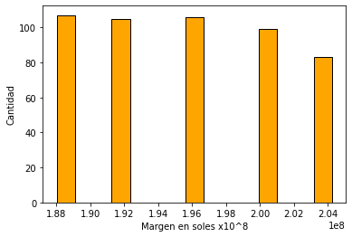

```python
#Histograma
plt.hist(dfFin["Margen_2022"],15,color='orange',ec='black')
plt.xlabel('Margen en soles x10^8')
plt.ylabel('Cantidad')
plt.show()
```